# 从 SGD 到 Muon 再到 PolarGrad：范数、最速下降与矩阵优化器的统一视角

> 一篇写给零基础读者的教程。不需要任何线性代数与优化器背景，从”矩阵内积是什么”一路走到 Muon 与 PolarGrad 的完整推导。全文中心只有一句话：**一个优化器 ≈ 一种范数的选择**——给定范数，最速下降的方向与步长都被唯一确定，SGD、SignSGD、pbSGD、Muon、PolarGrad 都是这台机器的产物。

> 本文将苏建林《Muon优化器赏析：从向量到矩阵的本质跨越》（kexue.fm/archives/10592）与 Keller Jordan《Muon: An optimizer for hidden layers in neural networks》两篇文章的知识点拆解后重新编排——先铺垫、后引用，每个公式出现时其全部前提都已讲透——并汇入 PolarGrad 原论文（arXiv:2505.21799）的框架与结果。文中一切数值例子均经 numpy 复算，可按文内步骤手工对拍。

## 〇、引言

本章交代三件事：全文要回答的问题（第 1 节）、一句话就能记住的中心论点（第 2 节）、读后面所有公式所需的记号约定（第 3 节）。

### 1. 优化器每一步在算什么

训练一个神经网络，说到底是在最小化一个损失函数（loss function）：模型预测离正确答案有多远，用一个数来度量；参数每挪动一点，这个数就变一点。优化器（optimizer）是每一步回答两个问题的规则：**往哪个方向挪？挪多远？**方向与步长，是理解一切优化器的两根轴。

如今的大模型，参数几乎全以矩阵形式存在：注意力层的查询、键、值投影，前馈网络的权重，都是成百上千行乘列的矩阵。每个参数对损失的影响由偏导数度量，全部偏导数按参数原来的形状排成的矩阵叫梯度（gradient），它指向损失上升最快的方向。可是经典优化器 SGD（随机梯度下降）与 Adam，做法都是把梯度矩阵拉平成一长串数字逐元素处理：每个坐标各算各的更新，从不问”这一串数字原本排成了什么矩阵”。

把矩阵当矩阵看——尊重它的乘法结构、它固有的”放大方向”——会得到什么不同的优化器？这是全文的核心问题。三位主角依次是：Muon（MomentUm Orthogonalized by Newton-Schulz），Keller Jordan 于 2024 年提出，在 NanoGPT 竞速任务上把达到 3.28 验证损失的纪录提速 1.35 倍（Keller Jordan）；苏建林对它的”范数视角”解读，其首图给出 NanoGPT（1.5B）对比：达到验证损失 2.90，Muon 只用 4.2B tokens，AdamW 要用 10B tokens（苏建林）；以及 2025 年的 PolarGrad 论文，在同一框架里把 Muon 丢掉的步长信息找了回来（PolarGrad 论文）。

读完本文，你应当能把任何优化器先拆成”方向 × 步长”两半，再追问一句：它凭什么这样选？

### 2. 中心命题：范数约束下的最速下降（全文论点预览）

一句话论点：**一个优化器 ≈ 一种范数的选择。**范数（norm）是”长度”概念的数学化，第 10 节给出严格定义；此刻只需知道：选定一种范数，就是选定一把度量”这一步走了多远”的尺子。

为什么尺子能决定优化器？在参数当前位置附近，损失近似是线性的，沿负梯度方向似乎能无限降下去——但线性近似只在附近成立，所以必须给步长设预算：这一步的”长度”不许超过预算。预算用范数画成一个球；在球内让线性近似下降最多的方向，称为该范数下的最速下降方向（steepest descent direction）。球的形状不同，最优点落的位置就不同，更新方向自然不同。第 16、17 节会把这套直觉证明成引理：方向由原范数决定，最优步长恰好正比于梯度的对偶范数（dual norm，第 13 节定义）——“范数决定方向，对偶范数决定步长”。

先尝一口数字，看看”换尺子”有多实在。同一个矩阵 $M=\begin{bmatrix}1&2\\3&4\end{bmatrix}$，用”拉平后的欧氏长度”量是 $5.4772$，用”对向量的最大放大倍数”量是 $5.4650$，用”各方向伸缩率之和”量是 $5.8310$——一个矩阵，三把尺子，三个答案（第 11、12 节给出这三把尺子的名字与算法）。

按这台”范数 → 方向”的机器，本文全部主角各就各位。表中名词先混个眼熟，都将在注明的节里严格定义：

| 优化器 | 步长预算的范数 | 最速下降方向 | 步长正比于 |
| --- | --- | --- | --- |
| SGD | 欧氏范数 ℓ2（第 10 节） | 负梯度方向 | 梯度的 ℓ2 长度 |
| SignSGD | ℓ∞ 范数（第 10 节） | 逐元素符号 sign(g)（第 18 节） | 梯度的 ℓ1 长度 |
| pbSGD | ℓp 范数族（第 10 节） | 符号与幂次的组合（第 18 节） | 梯度的 ℓq 长度 |
| Muon | 谱范数（第 11 节） | msign，矩阵符号函数（第 21 节） | 近似常数（第 26 节） |
| PolarGrad | 谱范数正则（第 37 节） | 同为 msign | 核范数，奇异值之和（第 12 节） |

全文只做两件事：上半场（第 4–15 节）补齐数学工具——内积、矩阵分解、范数、三条不等式；下半场（第 16–44 节）用同一台机器把上表每一行从头到尾推出来，不跳步。读完全书，面对任何一个新优化器，你的第一个问题应该是：它选了哪把尺子？

### 3. 记号与阅读约定

全文记号统一如下表，每个记号第一次真正登场时还会现场再讲；此刻不必背，用到随时回查。

| 记号 | 含义 | 首见节 |
| --- | --- | --- |
| W | 参数矩阵，m 行 n 列 | 第 16 节 |
| G | 梯度矩阵，与 W 同形 | 第 16 节 |
| Mₜ | 动量缓冲，t 为迭代步数 | 第 27 节 |
| Δ | 一步的更新量 | 第 16 节 |
| Aᵀ | 矩阵转置（行列互换） | 第 4 节 |
| tr(·) | 迹：方阵对角线元素之和 | 第 4 节 |
| ⟨A,B⟩ | 矩阵内积，等于 tr(AᵀB) | 第 4 节 |
| ‖x‖p | 向量 p-范数 | 第 10 节 |
| ‖A‖F | Frobenius 范数：拉平后的欧氏长度 | 第 4 节 |
| ‖A‖2 | 谱范数，等于最大奇异值 σmax | 第 11 节 |
| ‖A‖* | 核范数，等于奇异值之和 | 第 12 节 |
| ‖·‖^d | 对偶范数 | 第 13 节 |
| A = UΣVᵀ | 奇异值分解，σ₁ ≥ σ₂ ≥ … | 第 7 节 |
| U[:,:r] | 取 U 的前 r 列，r 为秩 | 第 7 节 |
| msign / sign | 矩阵符号函数 / 逐元素符号 | 第 21 节 |
| A ⪰ 0 | A 半正定 | 第 5 节 |
| κ₂、κG、κH | 条件数（矩阵 / 梯度 / Hessian） | 第 6、35 节 |
| η、γₖ | 学习率（PolarGrad 章用 γₖ 对齐原论文） | 第 16、37 节 |

为什么要专门用一节统一记号？因为矩阵优化器的文献记号相当混乱：同一个”对偶范数”，苏建林记作上标 $\dagger$（苏建林），Keller Jordan 的博客用 $\|\cdot\|_{2\to2}$ 这类写法（Keller Jordan），PolarGrad 论文又另有习惯。本文全部译成上表的一套记号，读原始文献时请自行对照。

两条约定请现在记住。其一，对偶范数一律记上标 d，并预先眼熟一个事实：**谱范数的对偶范数恰好是核范数**，即 $(\|\cdot\|_2)^d=\|\cdot\|_*$。这不是定义，而是一个要证的定理（第 15 节），也是全书从”向量优化器”跨到”矩阵优化器”的枢纽等式——看到星号就该想到”谱范数的对偶”。其二，公式不编号，一律用名字引用（如”对偶范数引理”“von Neumann 不等式”），跨节引用会写明节号。

数值纪律：文中一切小数都用 numpy 复算过，矩阵数字统一保留 4 位小数；只有整数例子（如 2×2 整数矩阵的乘法）是手算的。除四则运算与一元微积分外不需要任何预备知识：用到什么，先讲什么。阅读建议：每节都是”动机、定义、推导、数字、收口”五件套，第一遍读不懂推导时，可以先只看动机与数字，把推导留到第二遍。

## 一、线性代数地基

本章备齐后面全部推导要用的矩阵工具，六节一线串：内积与迹（第 4 节）→ 对称矩阵与特征值分解（第 5 节）→ Hessian 与曲率（第 6 节）→ 奇异值分解（第 7 节）→ 极分解（第 8 节）→ 四种分解的关系地图（第 9 节）。

### 4. 矩阵内积与迹：$\langle A,B\rangle=\operatorname{tr}(A^\top B)$

**动机。**后面要反复回答”更新方向与梯度方向有多一致”，这需要度量两个矩阵的”夹角”——一个矩阵版的点积。第 26 节推导 Muon 时，第一步就是把”损失的一阶近似下降量”写成 $\langle G,\Delta\rangle$，本节就是为它备料。

**定义。**把两个同形矩阵 $A,B$ 对应位置的元素相乘再全部相加，所得标量称为矩阵内积（inner product）：

$$\langle
A,B\rangle:=\sum_{i,j}A_{ij}B_{ij}.$$

方阵对角线元素之和称为迹（trace），记 $\operatorname{tr}(A)$。内积有一个更好用的等价写法：

$$\langle
A,B\rangle=\operatorname{tr}(A^\top B),$$

其中 $A^\top$ 是 $A$ 的转置（transpose）：行列互换，$(A^\top)_{ij}=A_{ji}$。

**推导。**$A^\top B$ 的第 $i$ 个对角元，是 $A$ 的第 $i$ 列与 $B$ 的第 $i$ 列对应元素相乘相加，即 $\sum_k A_{ki}B_{ki}$；把它对 $i$ 求和，正好是把所有位置的对应乘积加一遍——两种写法逐字相等。

**数值。**取 $A=\begin{bmatrix}1&2\\3&4\end{bmatrix}$、$B=\begin{bmatrix}0&1\\1&0\end{bmatrix}$。逐元素算：$1\cdot0+2\cdot1+3\cdot1+4\cdot0=5$；算乘积 $A^\top B=\begin{bmatrix}3&1\\4&2\end{bmatrix}$，迹为 $3+2=5$。一致。

迹有两条后文天天用的性质。线性性：$\operatorname{tr}(aA+bB)=a\,\operatorname{tr}(A)+b\,\operatorname{tr}(B)$。循环性：

$$\operatorname{tr}(ABC)=\operatorname{tr}(BCA)=\operatorname{tr}(CAB),$$

即把乘积整体循环轮换不改变迹（注意：不是任意交换顺序）。整数验证：$A,B$ 同上，取 $C=\begin{bmatrix}1&1\\0&1\end{bmatrix}$，则 $ABC=\begin{bmatrix}2&3\\4&7\end{bmatrix}$、迹为 $9$；$CAB=\begin{bmatrix}6&4\\4&3\end{bmatrix}$、迹为 $6+3=9$。相等。

一个特别重要的特例是 $B=A$：$\langle A,A\rangle=\operatorname{tr}(A^\top A)$ 等于全部元素的平方和，永远非负。对它开根号，记

$$\|A\|_F:=\sqrt{\langle
A,A\rangle},$$

称为 Frobenius 范数（Frobenius norm）——就是把矩阵拉平成向量后的欧氏长度，因此它天然度量”矩阵离零矩阵有多远”；第 25 节还会用它度量”矩阵离最近的正交矩阵有多远”。例如上面的 $A$：平方和 $1+4+9+16=30$，故 $\|A\|_F=\sqrt{30}=5.4772$。它凭什么够格叫”范数”，第 10 节用三条公理补票。另外，内积还有一条 Cauchy–Schwarz 不等式 $|\langle A,B\rangle|\le\|A\|_F\|B\|_F$，是第 15 节”不等式三件套”的第一件。

**收口。**第 15 节的不等式、第 17 节的核心引理、第 26 节 Muon 的推导，主角全是 $\langle G,\Delta\rangle$ 这个内积与迹的循环性。

### 5. 对称矩阵、特征值分解与半正定

**动机。**第 7 节算奇异值分解时，第一步永远是面对 $M^\top M$。任意矩阵自己未必对称，但它的格拉姆矩阵（Gram matrix）$M^\top M$ 天生有两个好性质：对称、半正定。“用对称矩阵研究任意矩阵”因此成为标准套路，本节先把这两个词讲透。

**定义与定理。**满足 $A^\top=A$ 的矩阵叫对称矩阵（symmetric matrix）。若 $Av=\lambda v$（$v\neq0$），称 $\lambda$ 为特征值（eigenvalue）、$v$ 为特征向量（eigenvector）：$A$ 作用在 $v$ 上只缩放、不转向。谱定理（spectral theorem）说：$n$ 阶对称矩阵恰有 $n$ 个两两正交的单位特征向量，把它们按列排成 $Q$、特征值对角排成 $\Lambda$，则

$$A=Q\Lambda Q^\top,\qquad Q^\top
Q=I.$$

大白话讲，对称矩阵的作用就是”转到主轴、沿各轴伸缩、再转回来”，没有剪切、没有歪斜。满足 $Q^\top Q=I$ 的 $Q$ 叫正交矩阵（orthogonal matrix）：列是两两正交的单位向量；几何上它是旋转与反射的复合，保持长度——$\|Qx\|^2=x^\top Q^\top Qx=x^\top x=\|x\|^2$。

对称矩阵 $A$ 若对一切 $x$ 都有 $x^\top Ax\ge0$，称为半正定（positive semidefinite, PSD），记 $A\succeq0$。它等价于”特征值全部非负”：令 $y=Q^\top x$，则 $x^\top Ax=y^\top\Lambda y=\sum_i\lambda_i y_i^2$；$\lambda$ 全非负时平方和必非负，反过来若某 $\lambda_i<0$，取 $y$ 为第 $i$ 个坐标向量即得负值。

格拉姆矩阵必半正定，一行证完：$x^\top M^\top Mx=(Mx)^\top(Mx)=\|Mx\|^2\ge0$。

半正定矩阵可以开根：定义 $A^{1/2}=Q\Lambda^{1/2}Q^\top$（对角元逐个开平方）；特征值全正时再定义 $A^{-1/2}=Q\Lambda^{-1/2}Q^\top$。自检：

$$A^{1/2}A^{1/2}=Q\Lambda^{1/2}Q^\top
Q\Lambda^{1/2}Q^\top=Q\Lambda Q^\top=A.$$

**数值。**$M=\begin{bmatrix}1&2\\3&4\end{bmatrix}$ 的格拉姆矩阵 $M^\top M=\begin{bmatrix}10&14\\14&20\end{bmatrix}$，对称一目了然。$2\times2$ 矩阵的特征值满足 $\lambda^2-\operatorname{tr}\cdot\lambda+\det=0$，其中行列式 $\det\begin{bmatrix}a&b\\c&d\end{bmatrix}=ad-bc$。代入迹 $30$、行列式 $4$：

$$\lambda^2-30\lambda+4=0\quad\Longrightarrow\quad
\lambda=15\pm\sqrt{221},$$

即 $\lambda_1=29.8661$、$\lambda_2=0.1339$，全部为正——此矩阵不仅半正定，还是正定的。它的两个特征向量这里先不求，第 7 节会把它们请出来：它们正是 SVD 中 $V$ 的两列。

**收口。**谱定理、半正定、矩阵平方根，是第 7、8 节奇异值分解与极分解的入场券。

### 6. Hessian 矩阵与曲率

**动机。**梯度只告诉我们局部的斜坡方向；想知道”步子能跨多大、哪个方向更陡”，得看二阶导数。本节是为第 19、35、36 节预热的概念工具。

**定义。**多元函数对每个变量求偏导数（固定其余变量、对单一变量求导），全部二阶偏导排成的矩阵叫 Hessian 矩阵（Hessian matrix）：$H_{ij}=\frac{\partial^2 f}{\partial x_i\,\partial x_j}$。求导次序可交换，所以 Hessian 矩阵对称。二次函数是最好的例子：设 $A$ 对称，

$$f(x)=\tfrac12 x^\top Ax+b^\top
x,$$

写成分量 $f=\frac12\sum_{i,j}A_{ij}x_ix_j+\sum_i b_ix_i$，逐项求一阶、二阶偏导，得梯度 $\nabla f(x)=Ax+b$，Hessian 恰好是 $A$ 本身。顺带一提：$A$ 正定时这个二次函数有唯一最小值点 $x^*=-A^{-1}b$，梯度下降每步都在向它靠近，靠近的快慢正是由 $A$ 的特征值说了算。

**曲率与条件数。**沿单位方向 $u$ 的二阶方向导数是 $u^\top Hu$，称为该方向的曲率（curvature）——函数沿 $u$ 弯曲的程度。由第 5 节谱定理，$H$ 的特征向量给出主方向，特征值就是各主方向上的曲率。最大与最小特征值之比

$$\kappa=\lambda_{\max}/\lambda_{\min}$$

叫条件数（condition number），度量各向异性；大白话说：峡谷有多扁。

**数值与直觉。**取 $A=\operatorname{diag}(3,1)$，等高线 $3x_1^2+x_2^2=$ 常数是一族椭圆：$x_1$ 方向曲率 $3$、$x_2$ 方向曲率 $1$，$\kappa=3$。梯度永远垂直于等高线；在扁峡谷里，它多半指向”对岸”而非谷底，于是梯度下降来回锯齿、被迫小步慢走——$\kappa$ 越大越严重。

**说明。**Hessian 装着全部二阶信息，但大模型的参数以亿计，存不下也算不动；全文因此以一阶方法为主，Hessian 只作”理解工具”在第 36 节回归，届时写作 $\kappa_H=L/\mu$：$L$ 是最大曲率、$\mu$ 是最小曲率，梯度下降的安全步长被 $1/L$ 卡住，而峡谷越扁（$\mu$ 越小）走得越慢。

**收口。**记住曲率与条件数两个词——第 35 节它们将换成”梯度条件数”重新登场，成为 PolarGrad 的直接动机。

### 7. 奇异值分解 SVD

**动机。**特征分解只属于对称方阵，而神经网络的参数矩阵又长又方、绝不对称。任意矩阵也需要一张”标准形”身份证，这就是奇异值分解（singular value decomposition, SVD）。

**定理。**任意实矩阵 $A$（$m\times n$）可分解为

$$A=U\Sigma V^\top,$$

其中 $U$（$m\times m$）、$V$（$n\times n$）都是正交矩阵，$\Sigma$ 的对角元非负、从大到小排列：$\sigma_1\ge\sigma_2\ge\cdots\ge\sigma_r>0$，称为奇异值（singular value）；正奇异值的个数 $r$ 就是矩阵的秩（rank）。几何上，$x\mapsto Ax$ 分三步：$V^\top$ 先旋转（或反射），$\Sigma$ 沿各坐标轴伸缩 $\sigma_i$ 倍，$U$ 再旋转一次——像把一张长方形纸先转向、沿两边拉压、再转向。

**怎么手算。**利用第 5 节谱定理：

$$A^\top A=(U\Sigma V^\top)^\top(U\Sigma
V^\top)=V\Sigma^2 V^\top,$$

这正是格拉姆矩阵 $A^\top A$ 的正交对角化：其特征值是 $\sigma_i^2$、特征向量是 $V$ 的各列（同理 $AA^\top=U\Sigma^2U^\top$）。为什么要绕道 $A^\top A$？因为 $A$ 自己不对称、不是方阵，第 5 节的谱定理用不上；而 $A^\top A$ 对称半正定，工具齐套。于是手算 SVD 分三步：算 $A^\top A$ 的特征值开根得 $\sigma$、特征向量得 $V$，再由 $U=AV\Sigma^{-1}$ 得 $U$（对角矩阵的逆就是对角元取倒数）。

**主例全程。**$M=\begin{bmatrix}1&2\\3&4\end{bmatrix}$：

1. $M^\top M=\begin{bmatrix}10&14\\14&20\end{bmatrix}$；
2. 特征方程 $\lambda^2-30\lambda+4=0$（第 5 节），解得 $\lambda=15\pm\sqrt{221}$，即 $\lambda_1=29.8661$、$\lambda_2=0.1339$；
3. 开根得奇异值 $\sigma_1=5.4650$、$\sigma_2=0.3660$；
4. 求 $V$ 的列：解 $(M^\top M-\lambda_1 I)v=0$，即 $(10-\lambda_1)v_1+14v_2=0$，取 $v\propto(14,\ \lambda_1-10)=(14,\ 19.8661)$，归一化得 $v_1=(0.5760,\ 0.8174)^\top$；对称矩阵不同特征值的特征向量必正交，故取 $v_2=(0.8174,\ -0.5760)^\top$；
5. 求 $U=MV\Sigma^{-1}$：逐列算 $u_i=Mv_i/\sigma_i$，得

$$U=\begin{bmatrix}0.4046&-0.9145\\0.9145&0.4046\end{bmatrix},\quad
\Sigma=\begin{bmatrix}5.4650&0\\0&0.3660\end{bmatrix},\quad
V^\top=\begin{bmatrix}0.5760&0.8174\\0.8174&-0.5760\end{bmatrix};$$

6. 重构验证：$U\Sigma V^\top$ 与 $M$ 之差的 Frobenius 范数为 $1.26\times10^{-15}\approx0$（软件算 SVD 可能把某对 $u_i,v_i$ 同时反号，乘积不变，属正常）。

再看奇异值重复的干净例：$M=\begin{bmatrix}3&4\\4&-3\end{bmatrix}$ 满足 $MM^\top=25I$，故 $\sigma_1=\sigma_2=5$；取 $U=M/5=\begin{bmatrix}0.6&0.8\\0.8&-0.6\end{bmatrix}$、$\Sigma=5I$、$V=I$ 就是一组 SVD——奇异值重复时 $U,V$ 的取法不唯一。

顺带一句：只保留最大的前 $k$ 个奇异值、丢掉其余，得到的是最佳秩-$k$ 近似，这叫截断 SVD（truncated SVD），第 14 节的低秩故事会用到。

**收口。**有了 $\sigma$ 与 $U,V$ 三块拼图，下一节把 $A$ 重新打包成”方向 × 幅度”。

### 8. 极分解与正交极因子

**动机。**每个复数都能写成 $z=re^{i\theta}$：模长乘方向。矩阵能不能也拆成”正交的方向 × 对称的伸缩”？能，这叫极分解（polar decomposition）。记住这个对应：复数里”非负实数” $r$ 的位置，矩阵版由”半正定矩阵”接任；复数里”模长为 $1$ 的方向” $e^{i\theta}$ 的位置，矩阵版由”正交矩阵”接任。

**定义与推导。**设 $A=U\Sigma V^\top$ 是第 7 节的 SVD。在中间塞进 $V^\top V=I$：

$$A=U\Sigma V^\top=U(V^\top V)\Sigma
V^\top=(UV^\top)(V\Sigma V^\top)=:U_p H.$$

两块各有名字：$H=V\Sigma V^\top$ 是 Hermitian 极因子，扮演 $|z|$ 的角色；$U_p=UV^\top$ 是正交极因子（orthogonal polar factor），扮演 $e^{i\theta}$ 的角色。两点核验。其一，$H$ 就是 $(A^\top A)^{1/2}$：第 7 节已算 $A^\top A=V\Sigma^2V^\top$，按第 5 节矩阵开根的定义即得 $H$；它对称、半正定（特征值就是 $\sigma_i\ge0$）。其二，$U_p$ 的列两两正交且都是单位向量：$(UV^\top)^\top(UV^\top)=VU^\top UV^\top=I$；方阵时 $U_p$ 就是正交矩阵，非方阵时称半正交。可见极分解不需要新算法：会算 SVD，就会算极分解。这套拆法在优化里反复出场，原因很直白：要改方向就动 $U_p$，要改幅度就动 $H$，两块互不干扰。

**数值。**仍是 $M=\begin{bmatrix}1&2\\3&4\end{bmatrix}$：

$$H=\begin{bmatrix}2.0580&2.4010\\2.4010&3.7730\end{bmatrix},\qquad
U_p=\begin{bmatrix}-0.5145&0.8575\\0.8575&0.5145\end{bmatrix}.$$

$H$ 对称，特征值为 $0.3660$ 与 $5.4650$——恰好是 $\sigma_2,\sigma_1$——半正定核验通过。直接相乘验证 $M=U_pH$，误差 $1.28\times10^{-15}$；也可以反过来用 $U_p=MH^{-1}$ 计算。认真的读者还可以用第 7 节手算的 $V,\Sigma$ 组装 $V\Sigma V^\top$，与这里的 $H$ 逐项对照——结果一致，手算量则交给软件消化。再看 $H$ 的迹：

$$\operatorname{tr}(H)=2.0580+3.7730=5.8310=\sigma_1+\sigma_2,$$

即”伸缩块”的迹等于奇异值之和。这个和叫核范数（nuclear norm），第 12 节正式定义，它将是 PolarGrad 步长的主角。

**预告。**”方向块” $U_p=UV^\top$ 会在第 21 节获得正式名字 $\operatorname{msign}(M)$，它就是 Muon 更新方向的来源；PolarGrad 论文则把参数更新直接写成 $X-\gamma\,\operatorname{tr}(H)\,U_p$（第 37 节推导），方向与幅度各就各位。

**收口。**方向与幅度分家之后，第四章拿走方向（msign），第七章把幅度请回来（PolarGrad）。

### 9. 四种分解的关系地图

本章出现了四种分解，先补最后一个对照项，再统一入表。QR 分解（QR decomposition）把列满秩矩阵写成 $A=QR$：$Q$ 的列正交归一、$R$ 上三角，来自 Gram–Schmidt 正交化——把每个列向量减去它在前面各列上的投影，再归一化。它在线性代数教材里地位很高，解最小二乘、算特征值都离不开；本文只借它做对照，因为两种文献里它常被错当成极分解的那一块。

| 分解 | 适用对象 | 形式 | 因子性质 | 本文角色 |
| --- | --- | --- | --- | --- |
| 特征分解 | 对称方阵 | A=QΛQᵀ | Q 正交，Λ 对角（特征值） | 曲率与 MᵀM 的钥匙（第 5、6 节） |
| SVD | 任意矩阵 | A=UΣVᵀ | U、V 正交，Σ 对角非负降序 | 全文核心工具（第 7 节起） |
| 极分解 | 任意矩阵 | A=UₚH | Uₚ（半）正交，H 对称半正定 | 方向 × 幅度分家（第 8、21、37 节） |
| QR | 列满秩矩阵 | A=QR | Q 列正交归一，R 上三角 | 仅作对照 |

一句话串讲：特征分解是对称方阵的身份证，回答”哪些方向只伸缩、不转向”；SVD 把这张身份证推广到任意矩阵，回答”哪些输入方向被送到哪些输出方向、各放大多少倍”；极分解则把身份证上的信息重新排成”方向 × 幅度”两块，回答”整体的方向是什么、整体的伸缩是什么”，方便按需取用。以第 7、8 节的同一个 $M$ 为例：它不对称，没有特征分解；SVD 读出 $\sigma_1=5.4650$、$\sigma_2=0.3660$；极分解把伸缩之和收进 $\operatorname{tr}(H)=5.8310$——同一矩阵，三种读法，各答一个问题。

一个必须澄清的误读（PolarGrad 论文点名警告）：QR 分解的 $Q$ 一般**不等于**正交极因子 $U_p$。$Q$ 由列空间的 Gram–Schmidt 过程产生，换一下列的顺序结果就变；$U_p$ 由奇异结构唯一决定，并且是”离 $A$ 最近的正交矩阵”——这条最优性第 25 节会证明。把 msign 当成”QR 的那个 $Q$“，是读 Muon 文献时最常见的张冠李戴，两者来源完全不同。

**收口。**地基打完，而且只要求看懂 2×2 的手算。下一章回答一个更朴素的问题：矩阵的”大小”到底怎么量？——范数登场。

## 二、范数：度量步长的尺子

本章地图：先给”长度”立规矩（范数三公理与向量 p-范数，第 10 节），再把尺子升级给矩阵（诱导范数与谱范数，第 11 节；Schatten 家族与核范数，第 12 节），随后引入本章枢纽——对偶范数（第 13 节），看清单位球的”尖角”如何决定最速方向的形状（第 14 节），最后用三条不等式把谱范数与核范数的对偶关系焊死（第 15 节）。

### 10. 范数三公理与向量 p-范数族

优化器的每一步都要回答”走多远”，而”远”需要一把尺子。第 2 节预告过：尺子不同，最速下降方向就不同，优化器也不同——所以先把”尺子”本身公理化。

**定义（范数）**：向量空间上的函数 $\|\cdot\|$ 满足以下三条，就称为范数（norm）：

1. **非负性**：$\|x\|\ge0$，且等号仅当 $x=0$ 成立——长度不为负，只有零向量长度为零；
2. **齐次性**：$\|cx\|=|c|\,\|x\|$——向量放大多少倍，长度就放大多少倍；
3. **三角不等式**：$\|x+y\|\le\|x\|+\|y\|$——两边之和不小于第三边，合走两段不比分头走更省。

满足这三条的函数都能当尺子。最常用的一族是 **p-范数**：对 $p\ge1$，

$$\|x\|_p=\Big(\sum_{i=1}^{n}|x_i|^p\Big)^{1/p}.$$

取同一个向量 $x=(3,-4)^\top$，逐个算三个特例（整数，可直接验算）：$p=1$ 时 $\|x\|_1=|3|+|-4|=7$，是各分量绝对值之和；$p=2$ 时 $\|x\|_2=\sqrt{3^2+(-4)^2}=\sqrt{25}=5$，就是中学的几何长度；$p\to\infty$ 时 $\|x\|_\infty=\max_i|x_i|=4$，只剩下最大分量的绝对值——$p$ 越大，尺子越”只看见最大的那个”。

把”长度不超过 1”的点全部画出来，得到**单位球**（unit ball）$\{x:\|x\|\le1\}$。同一句话在三种范数下画出三种形状（见图）：$\ell_1$ 单位球是顶点在 $(\pm1,0)$、$(0,\pm1)$ 的菱形；$\ell_2$ 单位球是圆；$\ell_\infty$ 单位球是顶点在 $(\pm1,\pm1)$ 的正方形。

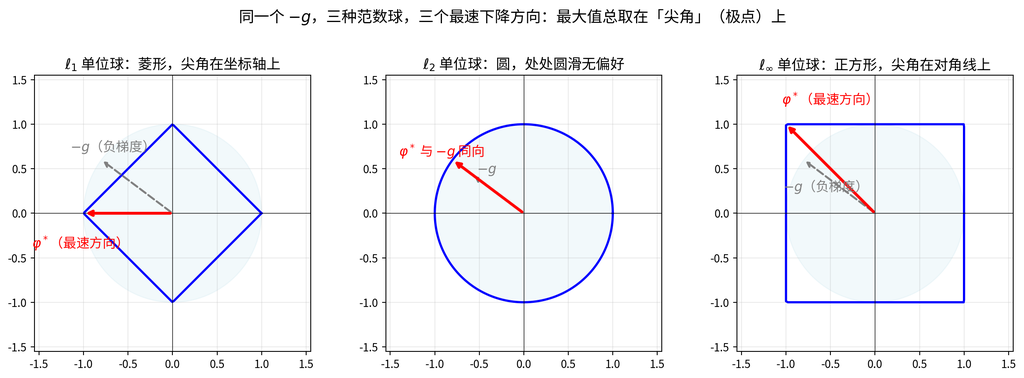

ℓ1/ℓ2/ℓ∞ 单位球

*图：二维平面上 ℓ1（菱形）、ℓ2（圆）、ℓ∞（正方形）三个单位球。ℓ1 的尖角戳在坐标轴上，ℓ∞ 的尖角戳在对角线上，ℓ2 处处圆滑没有角。后面会看到：线性函数在单位球上的最大值总盯着尖角取，所以球的形状决定了最速下降方向的形状。*

单位球是范数的”身份证”：球定了，范数就被唯一确定。第 14 节将看到，哪里尖、哪里平，直接决定第 18 节各个优化器的更新方向。

### 11. 诱导范数：谱范数 = 最大奇异值

矩阵是线性映射（第 7 节：旋转、伸缩、再旋转）。问”矩阵多大”，最自然的问法是：它最多能把一个单位向量拉长多少倍？这个倍数本身就是一把尺子。

**定义（诱导范数与谱范数）**：由向量 2-范数诱导（induced）的矩阵范数

$$\|A\|_2=\max_{\|x\|_2=1}\|Ax\|_2$$

称为**谱范数**（spectral norm），即 $A$ 作为线性映射的最大放大倍数。

**定理**：$\|A\|_2=\sigma_{\max}(A)$，谱范数等于最大奇异值。

**证明**（用第 7 节的 SVD $A=U\Sigma V^\top$，分四步）：

第一步，甩掉 $U$：$\|Ax\|_2=\|U\Sigma V^\top x\|_2$。第 5 节说过正交矩阵保长度，所以 $\|U(\Sigma V^\top x)\|_2=\|\Sigma V^\top x\|_2$。

第二步，换变量 $y=V^\top x$。$V^\top$ 也是正交矩阵，同样保长度，故 $\|y\|_2=\|x\|_2=1$；反过来任取单位 $y$，令 $x=Vy$ 也是可行的单位向量。于是问题等价于

$$\max_{\|y\|_2=1}\|\Sigma
y\|_2=\max_{\|y\|_2=1}\sqrt{\sigma_1^2y_1^2+\cdots+\sigma_r^2y_r^2}.$$

第三步，放缩：根号里是以 $y_i^2$ 为权重的加权平均，每个系数 $\sigma_i^2\le\sigma_1^2$，而权重之和 $\sum y_i^2=1$，所以整体不超过 $\sigma_1^2$。

第四步，取到上界：把全部权重押在最大的系数上，即取 $y=e_1=(1,0,\ldots,0)^\top$，此时 $\|\Sigma e_1\|_2=\sigma_1$。最大值就是 $\sigma_1$，证毕。$\square$

**数值**（N1）：第 7 节算过 $M=\begin{bmatrix}1&2\\3&4\end{bmatrix}$ 的奇异值 $\sigma_1=5.4650$、$\sigma_2=0.3660$，故 $\|M\|_2=5.4650$；而 F 范数 $\|M\|_F=\sqrt{30}=5.4772$。谱范数更小并非巧合：$\sigma_{\max}=\sqrt{\sigma_{\max}^2}\le\sqrt{\sum_i\sigma_i^2}=\|A\|_F$——谱范数只量”最强的一个方向”，F 范数把强弱全算了进去。

**次可乘性**（submultiplicativity）：谱范数满足 $\|AB\|_2\le\|A\|_2\|B\|_2$——$ABx$ 的放大倍数不超过”先被 $B$ 放大、再被 $A$ 放大”的两段乘积，由定义一行推出。但不是每个叫”范数”的函数都行：逐元素最大值 $\|A\|_{\max}=\max_{i,j}|a_{ij}|$ 就不满足——PolarGrad 论文给出全 1 矩阵 $J$ 的反例：$J^2=2J$，于是 $\|J^2\|_{\max}=2>1=\|J\|_{\max}\cdot\|J\|_{\max}$（PolarGrad 论文）。这个反例将在第 19 节成为”矩阵参数不能随便选范数”的关键证据。

谱范数 $=\sigma_{\max}$ 与次可乘性，是第 19 节论证”矩阵参数配谱范数”、第 26 节推出 Muon 的两块基石。

### 12. Schatten 范数家族：核范数、F 范数、谱范数一家亲

手上已有两种矩阵范数：谱范数（$\sigma_{\max}$，第 11 节）与 F 范数（$\sqrt{\sum\sigma_i^2}$，第 4 节）。它们看似各干各的，其实是一家。

**定义（Schatten p-范数）**：把矩阵 $A$ 的全部奇异值排成向量 $\sigma=(\sigma_1,\ldots,\sigma_r)$，对它套第 10 节的向量 p-范数：

$$\|A\|_{S_p}=\|\sigma\|_p=\Big(\sum_{i}\sigma_i^p\Big)^{1/p}.$$

三个熟悉的范数立刻各就各位：$p=\infty$ 时 $\|\sigma\|_\infty=\sigma_{\max}$，正是谱范数 $\|A\|_2$；$p=2$ 时 $\|\sigma\|_2=\sqrt{\sum\sigma_i^2}=\sqrt{\operatorname{tr}(A^\top A)}$，正是 F 范数 $\|A\|_F$；$p=1$ 时 $\|\sigma\|_1=\sum_i\sigma_i$，这是新角色——**核范数**（nuclear norm），记作 $\|A\|_*$。也就是说，**核范数就是奇异值之和**：矩阵范数三兄弟，只是对同一组奇异值换了三把向量尺子（Schatten 范数；PolarGrad 论文附录 A 正是用它统一处理这类”酉不变范数”）。

**数值**（N1）：$M$ 的奇异值是 $5.4650$ 与 $0.3660$，故

$$\|M\|_*=5.4650+0.3660=5.8310.$$

**半正定特例**：若 $A\succeq0$（第 5 节），奇异值就是特征值，于是 $\|A\|_*=\sum_i\lambda_i=\operatorname{tr}(A)$。第 8 节的 Hermitian 极因子 $H$ 恰是半正定的，那里的 $\operatorname{tr}(H)=5.8310$ 其实就是 $\|M\|_*$——极分解早已把核范数偷偷塞给了我们。

由定义还能读出两条后文要用的性质。其一，**酉不变性**（unitary invariance）：正交矩阵左乘或右乘不改变奇异值（第 7 节的 SVD 把它们直接吸收掉），所以一切 Schatten 范数在正交变换下不变——第 19 节将以此批评逐元素范数”不配当矩阵范数”。其二，**秩 1 时三兄弟合体**：只剩一个非零奇异值，$\sigma_{\max}=\sqrt{\sum\sigma_i^2}=\sum\sigma_i$，三种范数相等——第 14 节会看到，秩 1 矩阵正是核范数球上的尖角。

一笔要还的债：称核范数为”范数”，需要三角不等式 $\|A+B\|_*\le\|A\|_*+\|B\|_*$。但 $A+B$ 的奇异值与 $A$、$B$ 各自的奇异值没有简单关系，直接验证无从下手；第 15 节末将用对偶表示给出干净证明，本节先声明结论。

Schatten 视角同时回答了一个后文反复出现的问题——核范数凭什么重要：它是奇异值向量的 $\ell_1$ 范数，而 $\ell_1$ 几何天生偏爱稀疏（第 14 节展开），这决定了它在矩阵世界里偏爱低秩。

### 13. 对偶范数

第 2 节预告的最速下降问题 $\max_{\|\varphi\|\le1}\langle g,\varphi\rangle$，其答案随范数而变。但注意这个最大值本身：它度量”用单位球里所有方向去探测 $g$，能激起多大响应”——量出的恰好是 $g$ 的另一种”大小”。第 17 节的核心引理正需要这个概念。

**定义（对偶范数）**：任给范数 $\|\cdot\|$，它的**对偶范数**（dual norm）是

$$\|g\|^d=\max_{\|\varphi\|\le1}\langle
g,\varphi\rangle.$$

它确实满足范数三公理：非负性与齐次性由定义逐条代入即得；三角不等式因为”$\langle g_1+g_2,\varphi\rangle=\langle g_1,\varphi\rangle+\langle g_2,\varphi\rangle$，联合的最大值不超过两个分别最大值之和”。

**广义 Hölder 不等式**：由定义立刻得到，对任意 $g$、$\varphi$ 都有

$$\langle
g,\varphi\rangle\le\|g\|^d\,\|\varphi\|.$$

证明只有一步：$\|\varphi\|\le1$ 时这就是定义本身；一般的 $\varphi$ 先除以 $\|\varphi\|$ 归一化再用定义，两边乘回去即得。别小看这一行，第 17 节全靠它。

常见范数的对偶配对如下（矩阵两行在第 15 节证明）：

| 范数 | 对偶范数 | 备注 |
| --- | --- | --- |
| ℓ1 范数 ‖x‖₁ | ℓ∞ 范数 ‖x‖∞ | 最尖的球配最平的球 |
| ℓ2 范数 ‖x‖₂ | ℓ2 范数 ‖x‖₂ | 自对偶 |
| ℓp 范数 ‖x‖p | ℓq 范数 ‖x‖q | 1/p+1/q=1 |
| F 范数 ‖A‖F | F 范数 ‖A‖F | 自对偶 |
| 谱范数 ‖A‖₂ = σmax | 核范数 ‖A‖* = Σσᵢ | 第 15 节证明 |

几何直觉：单位球越尖，对偶球越平。$\ell_1$ 菱形的尖角戳在坐标轴上，它的对偶 $\ell_\infty$ 恰好是把坐标轴方向压得最扁的正方形；$\ell_2$ 的圆处处一样圆，对偶还是圆。更精确地说，$\|g\|^d$ 的最大值总在单位球的”尖角”（极点）上取到，这个取到最大值的 $\varphi^*$ 称为 $g$ 的支撑方向——第 14 节就研究这些尖角。

**数值例**：用 $\ell_\infty$ 单位球探测 $g=(3,-4)^\top$，即 $\max_{\|\varphi\|_\infty\le1}(3\varphi_1-4\varphi_2)$。每个分量独立，$\varphi_1$ 取 $1$、$\varphi_2$ 取 $-1$ 时最大，最大值为 $3+4=7$，恰是 $\|g\|_1$——印证了表中”$\ell_\infty$ 的对偶是 $\ell_1$“，取等方向 $\varphi^*=(1,-1)^\top$ 正是正方形的顶点。

对偶范数是本章枢纽：第 14 节用它看极点，第 15 节用它证明谱范数的对偶是核范数，第 17 节用它把”范数的选择”翻译成”优化器的方向与步长”。

### 14. 单位球的极点与低秩性

第 13 节末尾说，对偶配对的最大值总取在”尖角”上。尖角的数学名字是极点，它是本节主角：优化器的更新方向，就是某个范数单位球上的一个极点。

**定义（极点）**：单位球中的点 $x$ 若不能表示成球内另外两个不同点的中点（不存在 $x=\frac{y+z}{2}$ 且 $y\ne z$、$y,z$ 都在球内），就称为**极点**（extreme point）。大白话：极点是球面上最突出的角，不躺在任何线段的内部。线性函数在凸球上的最大值一定能在某个极点处取到——所以”最速下降方向长什么样”等价于”这个范数球的极点长什么样”。

逐个数五个球的极点：

- $\ell_\infty$ 球（正方形）：极点是全体顶点，即每个分量都取 $\pm1$ 的向量——第 18 节将看到，这给出 SignSGD 的逐元素 $\operatorname{sign}(g)$ 方向；
- $\ell_1$ 球（菱形）：极点是 $\pm e_i$，即只有一个分量为 $\pm1$、其余为 0 的坐标轴端点——对应第 18 节的贪心坐标下降，一步只动一个分量；
- $\ell_2$ 球（圆）：整个球面都是极点，没有任何偏好方向——所以 SGD 老老实实沿梯度本身走；
- 谱范数单位球：极点恰是（半）正交矩阵（第 8 节见过）——第 26 节，这就是 Muon 更新方向的几何身份；
- 核范数单位球：极点是秩 1 矩阵 $\pm uv^\top$（$u,v$ 为单位向量）。

**数值例**：继续用 $g=(3,-4)^\top$ 在三种球上找支撑方向。$\ell_1$ 球上，最大响应 $4$ 取在极点 $-e_2=(0,-1)^\top$——因为 $|-4|>|3|$，押注最大分量最划算，这就是一步贪心坐标；$\ell_2$ 球上，最大值 $5=\|g\|_2$ 取在 $g/5=(0.6,-0.8)^\top$，球面处处可为极点，不偏爱任何坐标；$\ell_\infty$ 球上则如第 13 节所算，取在顶点 $(1,-1)^\top$。三种范数、三种极点、三种方向——优化器的分野全在这里。

**低秩性**：这份清单解释了一个重要现象——范数的几何决定解的结构。两个方向各说一遍。

1. 谱范数约束下，最速方向落在半正交极点上，其秩等于梯度的秩 $r$；大模型的梯度矩阵常近似低秩，于是 Muon 的更新方向天然低秩，不含”所有方向雨露均沾”的噪声（Keller Jordan）。
2. 反过来，想让解低秩，就去惩罚核范数：核范数球的极点是秩 1 矩阵，最小化”目标 + 核范数惩罚”的解会被推向这些极点，即压成低秩矩阵。矩阵的秩是离散量、无法直接优化，核范数是它最紧的凸替身（凸松弛，convex relaxation）——矩阵补全正是靠这一招从残缺数据里恢复低秩矩阵。

极点概念是第 18 节逐个推出向量优化器、第 26 节推出 Muon 的几何钥匙：每个优化器，都是在某个范数球的极点上落脚。

### 15. 不等式三件套：Cauchy–Schwarz、Hölder、von Neumann

前面欠下的债（谱↔︎核对偶、核范数三角不等式）以及第 17、26、37 节的全部推导，都靠本节三条不等式收口。

**（一）Cauchy–Schwarz 不等式**：$|\langle A,B\rangle|\le\|A\|_F\|B\|_F$。

**证明**（判别式法）：对任意实数 $t$，由内积的非负性（第 4 节：$\langle X,X\rangle$ 是全部元素平方和）有

$$0\le\langle
A+tB,\,A+tB\rangle=\|A\|_F^2+2t\langle
A,B\rangle+t^2\|B\|_F^2.$$

右端是 $t$ 的二次函数且首项系数 $\|B\|_F^2\ge0$，它恒非负，说明它至多有一个实根，故判别式必须非正：

$$\big(2\langle
A,B\rangle\big)^2-4\|B\|_F^2\|A\|_F^2\le0
\quad\Longrightarrow\quad
\langle A,B\rangle^2\le\|A\|_F^2\|B\|_F^2,$$

两边开方即得（$B=0$ 时两边都是 0，平凡成立）。$\square$

**（二）Hölder 不等式**（陈述与取等方向）：$|\langle g,\varphi\rangle|\le\|g\|_q\|\varphi\|_p$，其中 $\frac1p+\frac1q=1$——这正是第 13 节”$\ell_p$ 的对偶是 $\ell_q$“的改写，$p=q=2$ 时退回 Cauchy–Schwarz。我们关心取等：使 $\langle g,\varphi\rangle$ 在 $\|\varphi\|_p\le1$ 上达到 $\|g\|_q$ 的方向是（苏建林）

$$\varphi_i^*=\frac{1}{\|g\|_q^{q/p}}\,\operatorname{sign}(g_i)\,|g_i|^{q/p}.$$

验证取等分两步。先算范数：$\|\varphi^*\|_p^p=\sum_i|g_i|^{q}/\|g\|_q^{q}=1$，确实在单位球面上。再算内积：$\langle g,\varphi^*\rangle=\sum_i|g_i|^{1+q/p}/\|g\|_q^{q/p}=\|g\|_q^{q}/\|g\|_q^{q-1}=\|g\|_q$，其中用到 $1+\frac qp=q$ 与 $\frac qp=q-1$（都由 $\frac1p+\frac1q=1$ 推出）。这个取等方向是第 18 节 pbSGD 的全部秘密。

**（三）von Neumann 迹不等式（特例）**：若 $\|B\|_2\le1$，则

$$\operatorname{tr}(A^\top
B)\le\sum_i\sigma_i(A)=\|A\|_*.$$

**证明**（苏建林的初等证法）：把 $A$ 的 SVD 写成秩一之和 $A=\sum_{i=1}^{r}\sigma_i u_i v_i^\top$（第 7 节），代入并用迹的循环性（第 4 节）：

$$\operatorname{tr}(A^\top
B)=\sum_{i=1}^{r}\sigma_i\,\operatorname{tr}(v_i u_i^\top
B)=\sum_{i=1}^{r}\sigma_i\,u_i^\top B v_i,$$

最后一步因为 $u_i^\top B v_i$ 是标量，迹就是它自己。再看因子 $u_i^\top B v_i$：由刚证的 Cauchy–Schwarz 与谱范数定义（第 11 节），

$$|u_i^\top B v_i|\le\|u_i\|_2\,\|B
v_i\|_2\le\|u_i\|_2\,\|B\|_2\,\|v_i\|_2\le1,$$

因为奇异向量都是单位向量且 $\|B\|_2\le1$。$\sigma_i>0$，每项 $\sigma_i\,u_i^\top B v_i\le\sigma_i$，求和即得结论。$\square$

von Neumann 不等式的一般形式是 $\operatorname{tr}(A^\top B)\le\sum_i\sigma_i(A)\sigma_i(B)$（不要求 $\|B\|_2\le1$），思路相同，但需用”奇异值重排不等式”控制交叉项，本文不证。

**推论（本章最高点）**：谱范数的对偶范数就是核范数，

$$\max_{\|\Phi\|_2\le1}\operatorname{tr}(G^\top\Phi)=\|G\|_*,\qquad\text{即}\qquad(\|\cdot\|_2)^d=\|\cdot\|_*.$$

论证分两半。上面的特例已给出”$\le$“（把 $B$ 换成任意 $\|\Phi\|_2\le1$ 的 $\Phi$）。再取 $\Phi=U_{[:,:r]}V_{[:,:r]}^\top=\sum_{i=1}^{r}u_i v_i^\top$：它是半正交矩阵，谱范数恰为 1（第 14 节的极点），且由奇异向量的正交性，$u_i^\top\Phi v_i=1$ 对每个 $i$ 成立，于是 $\operatorname{tr}(G^\top\Phi)=\sum_i\sigma_i=\|G\|_*$，上界被取到。这个取等方向 $\Phi=U_{[:,:r]}V_{[:,:r]}^\top$ 是后文一切的关键：第 21 节将给它起名 msign，第 26 节会认出它就是 Muon 的更新方向，第 37 节（PolarGrad 论文）会再乘上这里的对偶范数 $\|G\|_*$ 作为步长。

**补证**（还第 12 节的债：核范数满足三角不等式）：用对偶表示把核范数写成一族线性函数的最大值 $\|A\|_*=\max_{\|\Phi\|_2\le1}\langle A,\Phi\rangle$，于是

$$\|A+B\|_*=\max_{\|\Phi\|_2\le1}\big(\langle
A,\Phi\rangle+\langle B,\Phi\rangle\big)\le\max_{\|\Phi\|_2\le1}\langle
A,\Phi\rangle+\max_{\|\Phi\|_2\le1}\langle
B,\Phi\rangle=\|A\|_*+\|B\|_*,$$

理由是”同一个 $\Phi$ 要同时伺候两项，不如两项各自挑最优的 $\Phi$“。非负性与齐次性由定义直接读出，核范数的范数身份成立。

**数值**（N6）：取等方向坐实下界——$\operatorname{tr}(M^\top(-UV^\top))=-5.8310=-\|M\|_*$；换一个随机方向 $\Delta$ 做对照，$\operatorname{tr}(M^\top\Delta)=2.2024$，不超过一般形式给出的上界 $\sum_i\sigma_i(M)\sigma_i(\Delta)=3.6476$，不等式成立。

至此第二章的工具备齐：对偶范数、广义 Hölder、谱↔︎核对偶、取等方向 $U_{[:,:r]}V_{[:,:r]}^\top$。第 17 节将把它们组装成全文引用最多的核心引理：范数决定方向，对偶范数决定步长。

## 三、最速下降：统一的优化器生成器

本章地图：第 16 节给优化器的每一步建立”局部模型”（一阶近似加步长预算），第 17 节证明这个模型的闭式解完全由对偶范数刻画，第 18 节拿四种向量范数试车（SGD、SignSGD、贪心坐标、pbSGD 依次掉出来），第 19 节讨论矩阵参数该配哪种范数，第 20 节正面回答”统一到底体现在哪里”。

### 16. 一阶近似与信赖域思想

梯度 $G$ 只刻画参数 $W$ 附近极小邻域内的斜坡；步子一旦迈大，损失的二阶弯曲就让这份局部情报失效。所以”沿什么方向走”必须和”走多远仍可信”配套回答——这就是本节的两件道具。

损失在 $W$ 处的一阶近似（first-order approximation）是

$$\mathcal L(W+\Delta)\approx \mathcal
L(W)+\langle G,\Delta\rangle,$$

其中 $\langle G,\Delta\rangle=\operatorname{tr}(G^\top\Delta)$ 是第 4 节的矩阵内积。右端关于 $\Delta$ 是线性的：不加限制时沿 $-G$ 方向可以无限下降，目标根本没有最小值——所以”预算”不是装饰，而是让”最小化一阶近似”这句话有意义的前提。于是”别走太远”有两种标准写法（苏建林）：硬约束——只在信赖域（trust region）$\|\Delta\|\le\rho$ 内最小化 $\langle G,\Delta\rangle$；软惩罚——最小化 $\langle G,\Delta\rangle+\dfrac{\|\Delta\|^2}{2\eta}$，用与步长平方成正比的惩罚把 $\Delta$ 拉住。这套”线性近似加范数预算”的框架有个名字：最速下降法（steepest descent）——所谓”最速”，永远相对于某一把范数尺子而言，这句话将在第 18 节变成四个具体的优化器。

为什么误差随步长平方增长？看个一维数值例子：$f(x)=x^2$，在 $x=3$ 处一阶近似是 $9+6\Delta$。取 $\Delta=1$，真实值 $16$、近似 $15$、误差 $1$；取 $\Delta=2$，真实值 $25$、近似 $21$、误差 $4$。步长翻倍、误差变四倍——被扔掉的高阶项量级正比于 $\Delta^2$。预算 $\rho$ 或惩罚系数 $\frac{1}{2\eta}$ 控制的正是这份”近似的可信度”：整数手算里 $\Delta$ 从 $1$ 到 $2$，误差严格按平方从 $1$ 放大到 $4$。信赖域得名于此：只有在这个域内，梯度提供的情报才值得信任。

两种写法哪个更基本？第 17 节的核心引理将证明：它们给出同一个方向，连最优步长都由同一个量——对偶范数——算出；二者的严格等价则留到第 20 节，用拉格朗日对偶一句话说清。

### 17. 核心引理：对偶范数给出最速方向与最优步长

第 16 节把每步优化归结为”范数几何下的线性最小化”。本节给出它的通解：方向由对偶配对决定，幅度由对偶范数决定。这是全文被引用最多的工具。

**引理 A（硬约束版）**：设 $\|\cdot\|^d$ 为 $\|\cdot\|$ 的对偶范数（第 13 节），则

$$\min_{\|\Delta\|\le\rho}\langle
G,\Delta\rangle=-\rho\,\|G\|^d,\qquad \Delta^*=-\rho\,\varphi^*,\quad
\varphi^*=\operatorname{argmax}_{\|\varphi\|=1}\langle
G,\varphi\rangle.$$

**引理 B（软惩罚版）**：

$$\min_{\Delta}\left\{\langle
G,\Delta\rangle+\frac{\|\Delta\|^2}{2\eta}\right\}=-\frac{\eta}{2}\bigl(\|G\|^d\bigr)^2,\qquad
\Delta^*=-s^*\varphi^*,\quad s^*=\eta\,\|G\|^d,$$

方向 $\varphi^*$ 与引理 A 相同。大白话：范数决定方向，对偶范数决定步长。注意 $\varphi^*$ 依赖范数的选择——换一把范数尺子，单位球的形状变了，“使内积最大的单位方向”也跟着变；这正是第 18 节一切结果的来源。

引理 A 的证明分两步，全程只用第 13 节的一件工具：广义 Hölder 不等式。第一步（下界）：对任意 $\|\Delta\|\le\rho$，由 $|\langle G,\Delta\rangle|\le\|G\|^d\|\Delta\|$，

$$\langle G,\Delta\rangle\ge-|\langle
G,\Delta\rangle|\ge-\|G\|^d\|\Delta\|\ge-\rho\,\|G\|^d.$$

第二步（取等）：由对偶范数的定义，$\langle G,\varphi^*\rangle=\|G\|^d$ 且 $\|\varphi^*\|=1$；取 $\Delta^*=-\rho\varphi^*$，则 $\|\Delta^*\|=\rho$ 且 $\langle G,\Delta^*\rangle=-\rho\|G\|^d$，下界被打满。证毕。值得停下来读一遍结论：最优值 $-\rho\|G\|^d$ 关于预算 $\rho$ 是线性的——预算翻倍，一阶近似下能拿到的下降也翻倍；而最优方向 $\varphi^*$ 与 $\rho$ 无关。方向与预算各管各的，这个分离在第 26 节推 Muon 时还会回来。

引理 B 的证明用方向—幅度解耦（苏建林；Bernstein–Newhouse）：把 $\Delta$ 写成 $\Delta=-s\varphi$，幅度 $s=\|\Delta\|\ge0$、方向 $\|\varphi\|=1$，目标函数变为 $\dfrac{s^2}{2\eta}-s\langle G,\varphi\rangle$。先固定 $s$ 对 $\varphi$ 取最小：等价于最大化 $\langle G,\varphi\rangle$，最大值就是 $\|G\|^d$，且与 $s$ 无关——方向与幅度就此解耦。再对标量 $s$ 求最小：$\dfrac{s^2}{2\eta}-s\|G\|^d$ 的导数是 $\frac{s}{\eta}-\|G\|^d$，零点为 $s^*=\eta\|G\|^d$，代回得最小值 $-\frac{\eta}{2}(\|G\|^d)^2$。证毕。对偶范数在这里不是硬插进来的新概念：第 13 节把它定义为”单位球上的最大响应”，两个引理只是把这句定义代回了局部目标函数。

方向选错值多少钱？第 15 节对 $G=\begin{bmatrix}1&2\\3&4\end{bmatrix}$ 算过：最优方向的响应 $\operatorname{tr}(G^\top\varphi^*)=5.8310=\|G\|_*$（谱范数之对偶正是核范数，第 26 节详解），而随手取的一个方向响应只有 $2.2024$，连一半都不到。

引理是台通用机器：喂什么范数，产什么优化器。第 18 节连喂四种向量范数。

### 18. 向量三例：SGD、SignSGD、贪心坐标与 pbSGD

引理 A/B 对第 10 节的整个 p-范数族都适用。本节逐个代入，看掉出来的是什么。

**ℓ2 ⇒ SGD。** ℓ2 自对偶（第 13 节），$\|g\|^d=\|g\|_2$；Cauchy–Schwarz 不等式（第 15 节）在方向与 $g$ 平行时取等：$\varphi^*=g/\|g\|_2$。代入引理 B：

$$\Delta^*=-\eta\|g\|_2\cdot\frac{g}{\|g\|_2}=-\eta
g,$$

$\|g\|_2$ 一除一乘恰好抵消——普通 SGD 就是 ℓ2 几何下的最速下降。

**ℓ∞ ⇒ SignSGD。** 对偶是 ℓ1（第 13 节）。取 $\varphi^*=\operatorname{sign}(g)$（逐元素符号）：$\|\varphi^*\|_\infty=1$ 且 $\langle g,\varphi^*\rangle=\sum_i|g_i|=\|g\|_1=\|g\|^d$，达到对偶配对。更新 $-\eta\|g\|_1\operatorname{sign}(g)$：各坐标只取符号、等步长前进，幅度信息全部收进标量 $\|g\|_1$（实践中常把它并进学习率）。几何上，ℓ∞ 球的极点正是 $\{\pm1\}^n$ 的顶点（第 14 节），方向落在符号向量上毫不意外。

**ℓ1 ⇒ 贪心坐标下降。** 对偶是 ℓ∞；ℓ1 球的极点是 $\pm e_i$（第 14 节），线性函数的最值必在极点取到。设 $i^*=\operatorname{argmax}_i|g_i|$，取 $\varphi^*=\operatorname{sign}(g_{i^*})e_{i^*}$，则 $\langle g,\varphi^*\rangle=|g_{i^*}|=\|g\|_\infty=\|g\|^d$。每步只更新梯度绝对值最大的那个坐标——这就是贪心坐标下降（greedy coordinate descent）。ℓ1 几何最”吝啬”：一步只动一个坐标，换取该坐标上最大的瞬时下降。

**ℓp ⇒ pbSGD。** 对偶是 ℓq，$\frac1p+\frac1q=1$（第 13 节）。第 15 节 Hölder 不等式的取等方向给出（苏建林原文式 (20)）

$$\varphi_i^*=\frac{\operatorname{sign}(g_i)\,|g_i|^{q/p}}{\|g\|_q^{q/p}},\qquad
\Delta^*=-\eta\|g\|_q\,\varphi^*,$$

以此为方向的优化器叫 pbSGD（Powered SGD，名字来自论文《pbSGD: Powered Stochastic Gradient Descent Methods for Accelerated Non-Convex Optimization》；“Powered”指方向里每个分量被取了 $\frac qp$ 次幂）。验证分两步（注意 $\frac1p+\frac1q=1$ 蕴含 $\frac qp=q-1$）：(i) 合法性，$\|\varphi^*\|_p^p=\dfrac{\sum_i|g_i|^{(q/p)p}}{\|g\|_q^{(q/p)p}}=\dfrac{\sum_i|g_i|^q}{\|g\|_q^q}=1$；(ii) 取等，$\langle g,\varphi^*\rangle=\dfrac{\sum_i|g_i|^{1+q/p}}{\|g\|_q^{q/p}}=\dfrac{\|g\|_q^q}{\|g\|_q^{q/p}}=\|g\|_q^{q-q/p}=\|g\|_q$。

两个极限各写两步，收回老朋友。**$p=2$**：(i) $q=2$、$\frac qp=1$，故 $\varphi_i^*=\operatorname{sign}(g_i)|g_i|/\|g\|_2=g_i/\|g\|_2$；(ii) $\Delta^*=-\eta\|g\|_2\varphi^*=-\eta g$，即 SGD。**$p\to\infty$**：(i) $q\to1$、$\frac qp\to0$，故 $|g_i|^{q/p}\to1$、$\varphi^*\to\operatorname{sign}(g)$；(ii) 步长 $s^*=\eta\|g\|_1$，即 SignSGD。

用第 10 节的 $g=(3,-4)^\top$ 汇总（$\|g\|_1=7$，$\|g\|_2=5$，$\|g\|_\infty=4$）：ℓ2 给方向 $g/5$、步长 $5\eta$；ℓ∞ 给方向 $(1,-1)^\top$、步长 $7\eta$；ℓ1 给方向 $(0,-1)^\top$、步长 $4\eta$。同一个梯度，三种几何，三种走法——机器是同一台，喂进去的范数不同而已。下表把四个结果归档，读法只有一种：范数换，机器不换。

[output not shown]

向量世界统一完毕。但神经网络的参数是矩阵——第 19 节问：矩阵该喂哪种范数？

### 19. 矩阵参数该选什么范数

引理 A/B 对矩阵照样成立（内积换成 $\langle G,\Delta\rangle=\operatorname{tr}(G^\top\Delta)$，第 4 节），问题只剩一个：矩阵范数选哪把尺子。本节做排除法。

**F 范数 ⇒ 退回 SGD。** $\|A\|_F$ 就是把矩阵拉平后的 ℓ2 范数（第 4 节），且自对偶（第 13 节）；方向 $G/\|G\|_F$、步长 $\eta\|G\|_F$，合起来 $\Delta^*=-\eta G$。矩阵化毫无新意——这恰好说明 SGD”看不见”矩阵结构。

**max 范数 ⇒ 逐元素 sign，但它不及格。** 把 ℓ∞ 照搬到矩阵得 $\|A\|_{\max}=\max_{i,j}|a_{ij}|$，它其实就是”拉平后的 ℓ∞“：$\|A\|_{\max}=\|\operatorname{vec}(A)\|_\infty$，所以最速方向正是把 SignSGD 逐元素搬进矩阵，$\operatorname{sign}(G)$。PolarGrad 论文批评它两条：(i) 它不是矩阵范数——次可乘性（第 11 节）失败：$2\times2$ 全 1 矩阵 $J$ 满足 $J^2=2J$，于是 $\|J^2\|_{\max}=2>1=\|J\|_{\max}\|J\|_{\max}$；配不起矩阵乘法的尺子，就不配叫矩阵的尺子；(ii) 它在正交变换下会改变，不保持奇异结构——逐元素取符号会扭曲奇异向量，而奇异向量正是矩阵的”方向”（第 7、8 节）。

**谱范数 ⇒ 三条理由**（苏建林、Keller Jordan 与 PolarGrad 论文的汇流）：(i) 矩阵是线性映射，谱范数就是最大放大倍数（第 11 节）；约束 $\|\Delta\|_2\le\rho$ 就是约束这层参数的扰动对输入的放大，逐层控制 Lipschitz 常数；(ii) 谱范数由矩阵乘法诱导、在正交变换下不变，与”矩阵作为整体”相容（它是 Schatten ∞ 范数，第 12 节）；(iii) 数值上恒有 $\|\cdot\|_2\le\|\cdot\|_F$（第 11 节），约束更紧、更本质。

仍是 $M=\begin{bmatrix}1&2\\3&4\end{bmatrix}$：$\|M\|_2=5.4650\le5.4772=\|M\|_F$。差距小是因为奇异值 $5.4650$ 与 $0.3660$ 悬殊——F 范数把所有奇异值平方相加，谱范数只认最强方向。三条理由其实能缩成一句：谱范数是”矩阵乘法自己的范数”。

选定谱范数，引理 A 的对偶配对方向就是答案。这个方向正是第四章的主角 msign（第 21 节定义），第 26 节收网。

### 20. “这种统一是体现在损失函数上吗？”——约束与正则的对偶

读到这里有个自然疑问：SGD、SignSGD、Muon 被说成”同一台机器的产物”，难道它们最小化的损失函数不同？

不是。全局损失 $\mathcal L(W)$ 对所有优化器是同一个，统一不体现在那里。统一体现在**每步的局部目标函数**上：每个优化器 = 损失的一阶近似 + 一种范数几何（硬约束 $\|\Delta\|\le\rho$，或软惩罚 $\|\Delta\|^2/(2\eta)$）。换范数即换优化器，损失本身一行未动。这个视角同时也是设计新优化器的图纸：想让更新具备某种几何偏好，就换对应的范数。

硬约束与软惩罚凭什么算同一个模型？拉格朗日对偶（Lagrange duality）一句话：硬约束问题里约束 $\|\Delta\|\le\rho$ 对应一个拉格朗日乘子，它恰好扮演软惩罚中 $\frac{1}{2\eta}$ 的角色；每个预算 $\rho$ 配一个 $\eta$，两种写法扫出同一条解轨迹。这个等价对任意范数成立，与本章选了哪把尺子无关。软版还附赠硬版没有的礼物：最优步长的闭式解 $s^*=\eta\|G\|^d$（第 17 节引理 B）——步长不必由人外生给定，它由对偶范数自动算出。

用第 18 节的 $g=(3,-4)^\top$ 对照：ℓ2 软版自动给出 $s^*=5\eta$；硬约束版想走出同一步，得有人先把预算设成 $\rho=5\eta$——“5”这个信息，软版免费、硬版外挂。

把这副对偶眼镜戴到谱范数上：第 37 节的 PolarGrad 正是把谱范数的软惩罚版精确解到底，于是自动获得硬版 Muon 拿不到的”核范数步长”。统一的故事到那时才闭环，而第 42 节的总表会把每个优化器按”局部目标函数里的范数”重新归档。

## 四、msign：矩阵的符号函数

本章地图：第 21 节从标量 sign 长出 msign 的定义，第 22、23 节用两组数字把它看透（含全文数值高潮），第 24 节推导逆平方根等价式，第 25 节给出它的几何身份——最优正交近似，第 26 节收网：从谱范数最速下降推出完整的 Muon。

### 21. 从 sign 到 msign：标量符号函数的矩阵化

SignSGD 把梯度逐元素取符号、抹掉大小只留方向，效果意外之好（第 18 节：它是 ℓ∞ 几何下的最速下降）。矩阵有没有自己的”符号”？极分解（第 8 节）早已把答案的两半备好了。

先看标量：$x\ne0$ 时 $\operatorname{sign}(x)=x/|x|$，它有三条性质——(i) 保留方向（正负号）；(ii) 幅值归一，$|\operatorname{sign}(x)|=1$；(iii) 对正缩放不变：$\operatorname{sign}(cx)=\operatorname{sign}(x)$（$c>0$）。取符号就是”扔掉大小、只留方向”。矩阵的”大小与方向”由极分解 $M=U_pH$ 分成”正交方向 $U_p$ 乘对称幅度 $H$“（第 8 节），于是矩阵符号函数（matrix sign function）定义为（苏建林）

$$\operatorname{msign}(M)=U_{[:,:r]}V_{[:,:r]}^\top=U_p,$$

其中 $M=U\Sigma V^\top$ 是 SVD（第 7 节），$r=\operatorname{rank}(M)$，$U_{[:,:r]}$ 表示取 $U$ 的前 $r$ 列。大白话：保留全部左、右奇异向量，把所有非零奇异值拍成 1。由极分解立得 $M=\operatorname{msign}(M)\,H$：msign 就是 $M$ 的”方向因子”，$H$ 是”幅度因子”，定义只是把第 8 节的分解倒过来读。

逐条核对三条性质：(i) 矩阵的”方向”正是奇异向量对，全部保留——SVD 的几何三步是 $V^\top$ 旋转、$\Sigma$ 沿轴伸缩、$U$ 再旋转（第 7 节），msign 把中间的伸缩换成恒等、两头的旋转原样保留，“方向”一词由此落到实处；(ii) 幅值归一：$\operatorname{msign}(M)$ 的奇异值是 $r$ 个 1（其余为 0）；(iii) $c>0$ 时 $cM$ 的 SVD 只是把 $\Sigma$ 乘 $c$、$U$ 与 $V$ 原样，故 $\operatorname{msign}(cM)=\operatorname{msign}(M)$。此外还有一条添头：$\operatorname{msign}(-M)=-\operatorname{msign}(M)$，与标量 sign 的奇性一致。

数值上，第 7 节的主角 $M=\begin{bmatrix}1&2\\3&4\end{bmatrix}$ 的奇异值是 $5.4650$ 与 $0.3660$；$\operatorname{msign}(M)$ 的两个奇异值则都是 $1$——大小被彻底抹平，方向原封不动。至于为什么敢叫”符号函数”：第 24 节将看到，它在标量、对角矩阵、列向量三种退化情形下一一收回 sign、逐元素 sign 与归一化，名字到那时才完全兑现。

定义有了，它长什么样？第 22 节先看一眼就能看穿的秩 1 情形。

### 22. msign = U[:,:r]V[:,:r]ᵀ 是什么：秩一外积例

定义里的截断记号 $U_{[:,:r]}$ 有点抽象。秩 1 矩阵只有一对奇异向量，是看清”拍平奇异值”的最小例子。

秩 1 矩阵都能写成外积 $M=ab^\top$：每一列都是 $a$ 的倍数、每一行都是 $b$ 的倍数，整张矩阵的信息量就是一个方向对 $(a,b)$ 外加一个强度。它的 SVD 几乎免费：取

$$u_1=\frac{a}{\|a\|_2},\qquad
v_1=\frac{b}{\|b\|_2},\qquad \sigma_1=\|a\|_2\,\|b\|_2,$$

验证一步：$Mv_1=a\,\dfrac{b^\top b}{\|b\|_2}=\|b\|_2\,a=\sigma_1u_1$，正是奇异值—奇异向量关系 $Mv_1=\sigma_1u_1$（第 7 节）。于是

$$\operatorname{msign}(M)=u_1v_1^\top=\frac{ab^\top}{\|a\|_2\|b\|_2}=\frac{M}{\sigma_1},$$

秩 1 时 msign 就是”除以唯一非零奇异值”：方向对 $(a,b)$ 原样保留，强度 $\sigma_1$ 被抽走，剩下的正是”纯方向”。放到优化语境里读：秩 1 梯度意味着所有坐标方向的信号都沿着同一对方向对齐，msign 对它做的只是尺度归一；而真实梯度矩阵通常不是秩 1，第 23 节的满秩例子才有戏可看。

取 $a=(1,2,3)^\top$、$b=(1,2)^\top$，则 $\|a\|_2=\sqrt{14}=3.7417$、$\|b\|_2=\sqrt5=2.2361$、$\sigma_1=\sqrt{70}=8.3666$，

$$M=\begin{bmatrix}1&2\\2&4\\3&6\end{bmatrix},\qquad
\operatorname{msign}(M)=u_1v_1^\top=\begin{bmatrix}0.1195&0.2390\\0.2390&0.4781\\0.3586&0.7171\end{bmatrix}.$$

抽一个元素对拍：$(3,2)$ 元素 $=\dfrac{a_3b_2}{\sigma_1}=\dfrac{6}{\sqrt{70}}=0.7171$。这个简单例子已经能区分 msign 与逐元素 sign：$\operatorname{msign}(M)$ 的元素是 $0.1195$、$0.7171$ 这类小分数，而不是 $\pm1$——矩阵符号不是逐元素符号，它记录的是奇异向量张成的几何，而不是每个坐标的正负。

这个 $3\times2$ 例子里 $r=1<2$，$\operatorname{msign}(M)$ 只是”部分等距”（partial isometry）：

$$\operatorname{msign}(M)^\top\operatorname{msign}(M)=v_1v_1^\top=\begin{bmatrix}0.2000&0.4000\\0.4000&0.8000\end{bmatrix}\ne
I.$$

原因正在截断：$U_{[:,:r]}$ 只取 $r$ 列，$\operatorname{msign}(M)^\top\operatorname{msign}(M)=V_{[:,:r]}V_{[:,:r]}^\top$ 是到 $M$ 的行空间的投影矩阵——msign 只在这 $r$ 个方向张成的子空间里像正交矩阵。换句话说，部分等距的意思是：它在行空间上保持长度，在与行空间正交的方向上输出零，“只在自己工作的方向上正交”。这就是定义中”$[:,:r]$“的确切含义，也是满秩与秩亏损的分界线：下一节满秩时投影就是单位阵。

秩 1 看懂了，第 23 节挑战 $2\times2$ 满秩的手算全流程。

### 23. 主例手算：M=[[1,2],[3,4]] 从 SVD 到 msign

前 22 节的每件工具都在 $M=\begin{bmatrix}1&2\\3&4\end{bmatrix}$ 上演练过。本节把它们串成一条流水线，亲手算出 $\operatorname{msign}(M)$——这是全文的数值高潮。选它当主例，因为它够小（能手算）又够一般（两个奇异值悬殊、行列式为负），msign 的每个非平凡之处都会露脸。

分五步，前四步是第 5、7 节结论的重放（推导细节见彼处）。第一步（格拉姆矩阵）：$M^\top M=\begin{bmatrix}10&14\\14&20\end{bmatrix}$。第二步（特征值）：迹为 $30$、行列式为 $4$，特征方程 $\lambda^2-30\lambda+4=0$，解为 $\lambda=15\pm\sqrt{221}$，即 $\lambda_1=29.8661$、$\lambda_2=0.1339$。第三步（奇异值，第 7 节：奇异值是 $M^\top M$ 特征值的平方根）：$\sigma_1=\sqrt{\lambda_1}=5.4650$、$\sigma_2=\sqrt{\lambda_2}=0.3660$。第四步（$V$ 与 $U$）：$v_1\propto(14,\,\lambda_1-10)=(14,\,19.8661)$，归一化得 $v_1=(0.5760,\,0.8174)^\top$，$v_2=(0.8174,\,-0.5760)^\top$；再由 $U=MV\Sigma^{-1}$ 得

$$U=\begin{bmatrix}0.4046&-0.9145\\0.9145&0.4046\end{bmatrix},\qquad
V^\top=\begin{bmatrix}0.5760&0.8174\\0.8174&-0.5760\end{bmatrix}.$$

（$U,V$ 的每一对 $u_i,v_i$ 都有整体符号自由——同时反号不改变 $u_iv_i^\top$，软件可能给出另一套符号，第 7 节已说明；这里取手算自然的一套。）

第五步（组装，把 $\Sigma$ 换成 $I$）：

$$\operatorname{msign}(M)=UV^\top=\begin{bmatrix}0.4046&-0.9145\\0.9145&0.4046\end{bmatrix}\begin{bmatrix}0.5760&0.8174\\0.8174&-0.5760\end{bmatrix}=\begin{bmatrix}-0.5145&0.8575\\0.8575&0.5145\end{bmatrix}.$$

组装这一步值得停顿：$UV^\top$ 与 $M=U\Sigma V^\top$ 共享同一对”旋转”，唯一区别是中间的 $\Sigma$ 被换成 $I$——msign 就是把”伸缩”从 $M$ 里摘出去。

验证两条。(i) 正交性：数值上 $\operatorname{msign}(M)\operatorname{msign}(M)^\top=\begin{bmatrix}1&0\\0&1\end{bmatrix}$，分毫不差。(ii) 反射：$\det M=-2<0$，而 $\det\operatorname{msign}(M)=-1$——它不是纯旋转，而是带反射的正交矩阵（呼应第 5 节：正交矩阵=旋转+反射）。含反射对优化无害：我们要的只是保持长度的方向变换，旋转与反射都满足。

再看奇异值简并的对照例：$M'=\begin{bmatrix}3&4\\4&-3\end{bmatrix}$ 满足 $M'M'^\top=25I$，$\sigma_1=\sigma_2=5$，即 $M'$ 本身已是”正交矩阵乘 5”，于是

$$\operatorname{msign}(M')=\frac{M'}{5}=\begin{bmatrix}0.6000&0.8000\\0.8000&-0.6000\end{bmatrix}.$$

归一化即正交化——msign 的全部非平凡性来自奇异值之间的差异。这个对照同时是一则预告：若某层梯度矩阵的奇异值接近简并，msign 与简单 rescale 几乎一样，“正交化”的收益就小；收益大小取决于奇异值的分散程度。

手算可行，但要过 SVD 这座桥。第 24 节给一把不含 $U,V$ 的代数钥匙。

SVD 太贵。等价式把 msign 改写成”逆平方根乘原矩阵”：它既是标量类比 $x/|x|$ 的闭环，也是第六章 Newton–Schulz 迭代的出发点。

**等价式**（苏建林）：满秩时

$$\operatorname{msign}(M)=(MM^\top)^{-1/2}M=M(M^\top
M)^{-1/2},$$

其中 $(\cdot)^{-1/2}$ 是第 5 节的矩阵逆平方根；秩亏损时把逆换成伪逆，结论不变。

证右式，分三步。第一步：把 $M=U\Sigma V^\top$（第 7 节）代入，$M^\top M=V\Sigma^2V^\top$（用了 $U^\top U=I$）。第二步：对半正定矩阵取矩阵函数（第 5 节），特征结构不动、对角元取 $-\frac12$ 次幂：$(M^\top M)^{-1/2}=V\Sigma^{-1}V^\top$。第三步：相乘，

$$M(M^\top M)^{-1/2}=U\Sigma V^\top\cdot
V\Sigma^{-1}V^\top=U\Sigma\Sigma^{-1}V^\top=UV^\top=\operatorname{msign}(M),$$

中间用了 $V^\top V=I$。左式同理：$MM^\top=U\Sigma^2U^\top$，故 $(MM^\top)^{-1/2}M=U\Sigma^{-1}U^\top\cdot U\Sigma V^\top=UV^\top$。两个等价式里选哪边取逆有讲究：$MM^\top$ 与 $M^\top M$ 一大一小，工程上总挑维度小的那边——第六章”高矩阵先转置”的技巧正来自这里。（长方形满秩时有一侧的逆要按伪逆理解；秩亏损时伪逆版仍给出 $U_{[:,:r]}V_{[:,:r]}^\top$，因为零奇异值对应的方向本就不出现在截断里。）

标量类比闭环：$M$ 是 $1\times1$ 矩阵 $(x)$ 时 $M^\top M=(x^2)$，于是 $x(x^2)^{-1/2}=\dfrac{x}{|x|}=\operatorname{sign}(x)$——第 21 节的类比在这里成为恒等式。

数值上，对同一个 $M$ 用三种算法各算一遍：$UV^\top$、$(MM^\top)^{-1/2}M$、$M(M^\top M)^{-1/2}$ 都得到 $\begin{bmatrix}-0.5145&0.8575\\0.8575&0.5145\end{bmatrix}$，两两最大差 $9.99\times10^{-16}$，即机器精度。

两个退化情形（苏建林）。(i) 对角矩阵 $M=\operatorname{diag}(m)$：$M^\top M=\operatorname{diag}(m_i^2)$，等价式逐对角元读出 $\operatorname{msign}(M)=\operatorname{diag}(\operatorname{sign}(m))=\operatorname{sign}(M)$——**Muon 作用在对角参数上就是带动量的 SignSGD，即 Signum 或其变体 Tiger**（Tiger 为苏建林提出的同类优化器）。(ii) 列向量 $m$（看成 $n\times1$ 矩阵）：$M^\top M=(\|m\|_2^2)$ 是 $1\times1$ 的，等价式给出 $\operatorname{msign}(m)=\dfrac{m}{\|m\|_2}$，即 ℓ2 归一化。同一个向量参数，看成对角阵得到 sign、看成列矩阵得到归一化——第 26 节”embedding 与 LayerNorm 参数该用谁”的讨论正源于此。

等价式只剩矩阵乘法与逆平方根；第六章将看到逆平方根可以用多项式迭代逼近，SVD 就此退场。

### 25. 最优正交近似：Muon/Signum/Tiger 同族

msign 还有一个几何身份：它是离 $M$ 最近的正交矩阵。这把”Muon 在干什么”翻译成一句人话——把动量投影到正交矩阵集合上；也把 Muon 与 Signum、Tiger 收进同一家族。

**定理**（满秩方阵 $m=n=r$；苏建林）：这类”找最近正交矩阵”的问题也叫正交 Procrustes 问题，而答案正是

$$\operatorname{msign}(M)=\underset{O^\top
O=I}{\operatorname{argmin}}\,\|M-O\|_F^2.$$

证明分五步。第一步（展开）：$\|M-O\|_F^2=\langle M-O,M-O\rangle=\|M\|_F^2+\|O\|_F^2-2\operatorname{tr}(MO^\top)$（第 4 节）。第二步：$O$ 正交则 $\|O\|_F^2=\operatorname{tr}(O^\top O)=n$，前两项与 $O$ 无关，问题等价于**最大化** $\operatorname{tr}(MO^\top)$。第三步（SVD 代入加迹循环性，第 4、7 节）：$\operatorname{tr}(MO^\top)=\operatorname{tr}(U\Sigma V^\top O^\top)=\operatorname{tr}(\Sigma\,V^\top O^\top U)$；记 $Q=V^\top O^\top U$，三个正交矩阵之积仍正交。第四步（对角元不超过 1）：$\operatorname{tr}(\Sigma Q)=\sum_i\sigma_iQ_{ii}$；单位向量的任何分量都不超过 1，正交矩阵的每列都是单位向量，故 $Q$ 的每个元素——特别地每个对角元——满足 $Q_{ii}\le1$；又 $\sigma_i>0$，所以 $\operatorname{tr}(\Sigma Q)\le\sum_i\sigma_i=\|M\|_*$（第 12 节）。第五步（取等）：等号要求所有 $Q_{ii}=1$；正交矩阵某列的对角元为 1 时该列只能是 $e_i$，故 $Q=I$，解出 $O=UV^\top=\operatorname{msign}(M)$。证毕。

数值对拍：理论最小值 $\|M\|_F^2+n-2\|M\|_*=30+2-2\times5.8310=20.3381$，与实际 $\|M-\operatorname{msign}(M)\|_F^2=20.3381$ 一致；对照候选都更大：$\|M-I\|_F^2=22.0000$，$\|M-\mathrm{Rot}(30^\circ)\|_F^2=22.3397$。

sign 有平行版本：$\operatorname{sign}(M)=\operatorname{argmin}_{O\in\{\pm1\}^{m\times n}}\|M-O\|_F^2$。证明一句话：F 范数逐元素求和，每个 $m_{ij}$ 独立地离 $\operatorname{sign}(m_{ij})\in\{+1,-1\}$ 最近。数值：$\|M-\operatorname{sign}(M)\|_F^2=14.0000$，而对照候选 $O=\begin{bmatrix}1&1\\1&-1\end{bmatrix}$ 给出 $30.0000$，逐元素 sign 确为最优。

于是同族关系清楚了：Muon = 动量 + 向（半）正交矩阵集投影；Signum/Tiger = 动量 + 向 $\{\pm1\}$ 矩阵集投影。约束集不同、思路相同；而这两个约束集恰好是相应范数单位球的极点集（第 14 节：谱范数球的极点是（半）正交矩阵，ℓ∞ 球的极点是 $\{\pm1\}$ 顶点）——“统一体现在哪”的答案再次落回第 20 节的局部目标函数。最后提一句：Fan–Hoffman 定理保证这个最优正交近似对任意酉不变范数都成立，不限于 F 范数（PolarGrad 论文 Thm A.3），第 37 节会用到。

几何身份备齐。第 26 节收网：谱范数最速下降的方向正是 msign。

### 26. Muon 出炉：谱范数最速下降全链推导

第 17 节的引理、第 19 节的范数选择、第 21 节的 msign——万事俱备。本节把 Muon 从”谱范数约束的最速下降”中完整推出，每一步标注它来自哪一节。

**定理**：谱范数预算 $\rho$ 下的最速下降问题是

$$\min_{\|\Delta\|_2\le\rho}\ \langle
G,\Delta\rangle\;=\;-\rho\,\|G\|_*,\qquad
\Delta^*=-\rho\,\operatorname{msign}(G),$$

即第 17 节引理 A 在谱范数下的逐步展开。

先澄清一个常见误读：$\langle G,\Delta\rangle$ **不是 F 范数**，而是 Frobenius 内积（第 4 节）——一个可正可负的标量，度量”$\Delta$ 与 $G$ 的对齐程度”；范数只出现在约束 $\|\Delta\|_2\le\rho$ 里。目标让内积尽量负（一阶近似降得最多），约束让步子不失控。

推导全链分五步。第一步：$\langle G,\Delta\rangle=\operatorname{tr}(G^\top\Delta)$（第 4 节，内积=迹）。第二步：SVD 展开 $G=\sum_{i=1}^r\sigma_iu_iv_i^\top$（第 7 节），代入并用迹的循环性（第 4 节）：

$$\operatorname{tr}(G^\top\Delta)=\sum_{i=1}^r\sigma_i\operatorname{tr}(v_iu_i^\top\Delta)=\sum_{i=1}^r\sigma_i\,u_i^\top\Delta
v_i.$$

第三步（约束入场）：$\|\Delta\|_2\le\rho$ 即最大放大倍数不超过 $\rho$（第 11 节），故 $\|\Delta v_i\|_2\le\rho$；由 Cauchy–Schwarz（第 15 节），$u_i^\top\Delta v_i\ge-\|u_i\|_2\|\Delta v_i\|_2\ge-\rho$。第四步（求和）：$\langle G,\Delta\rangle\ge-\rho\sum_i\sigma_i=-\rho\|G\|_*$（核范数=奇异值之和，第 12 节；这正是第 15 节 von Neumann 不等式的特例）。第五步（取等）：$\Delta^*=-\rho\sum_iu_iv_i^\top=-\rho\,\operatorname{msign}(G)$（第 21 节），此时 $\|\Delta^*\|_2=\rho$ 且 $\langle G,\Delta^*\rangle=-\rho\|G\|_*$，下界打满。证毕——这正是”谱范数的对偶范数是核范数”（第 13、15 节）的取等方向。

数值闭环：对 $M=\begin{bmatrix}1&2\\3&4\end{bmatrix}$，$\operatorname{tr}(M^\top(-UV^\top))=-5.8310=-\|M\|_*$，理论下界分毫不差；作为参照，随手取的一个方向响应只有 $2.2024$。

从定理到算法还差四步：把预算 $\rho$ 改名学习率 $\eta$；随机梯度有噪声，把 $G$ 换成动量 $M_t=\beta M_{t-1}+G_t$（它是对真实梯度更准的估计，第五章细说）；$\operatorname{msign}$ 用 Newton–Schulz 迭代近似计算（第六章）；再加解耦权重衰减（decoupled weight decay）。得到 Muon 完整更新（苏建林式 (1)）：

$$M_t=\beta M_{t-1}+G_t,\qquad
W_t=W_{t-1}-\eta\bigl(\widetilde{O}_t+\lambda W_{t-1}\bigr),$$

其中 $\widetilde{O}_t$ 是 $\operatorname{msign}(M_t)$ 乘上形状缩放。缩放的两种出处必须分清：(i) Keller Jordan 的公开实现用 $\sqrt{\max(1,m/n)}$，即按宽高比缩放，**没有 0.2**；(ii) $0.2\sqrt{\max(m,n)}$ 出自 **Moonshot《Muon is Scalable》报告**，不是 Keller 博客——它把更新的 RMS（均方根幅度）对齐到 AdamW 更新的典型量级 $0.2$，从而直接复用为 AdamW 调好的学习率与权重衰减。这些因子不是经验玄学：第 40–41 节将看到，它们恰好是把”谱范数 $1$“翻译成特征学习理论所要求尺度的汇率。

哪层用哪个：隐藏层矩阵用 Muon；embedding、输出头、标量与向量参数用 AdamW（Keller 的实证结论；苏建林补充：embedding 使用上稀疏，更合理的是按多个向量独立处理，呼应第 24 节的列向量退化）；Q、K、V 分开做 msign 优于合并成一个大矩阵（Keller 实证）。

Muon 的方向故事讲完了，但它把奇异值全部拍平、幅度信息尽失。这个代价有多大、怎么找回来？第七章 PolarGrad 接棒。

## 五、动量与 Nesterov

本章地图：动量的指数平均直觉（第 27 节）→ Nesterov 两种形式的等价（第 28 节）→ 动量与 msign 的接法（第 29 节）。读完本章，第 26 节的裸 Muon 就补全为实用版 Muon。

### 27. 动量：噪声下的指数平均

训练用的是 mini-batch 随机梯度：每一步算出的不是真梯度，而是”真梯度加一份采样噪声”。在第 6 节的扁峡谷里，噪声让更新来回锯齿：一步撞到左壁、下一步弹到右壁，垂直于峡谷方向的分量反复抵消，沿谷底前进的分量却很小。动量（momentum）——最早是 Polyak 的重球法（heavy ball）——是最经典的降噪与加速装置：把小球换成滚动的重球，颠簸被惯性抹平，长直方向上越滚越快。

定义（重球动量）：维护一个与梯度同形状的缓冲 $M_t$，

$$M_t=\beta M_{t-1}+G_t,\qquad
M_0=0,$$

其中 $\beta\in[0,1)$ 是动量系数（Muon 默认 $0.95$）。大白话：$M_t$ 是历史梯度的”指数加权平均”——新梯度全额入账，旧梯度每过一步打一个 $\beta$ 折。

推导：把递推逐层展开，

$$M_t=G_t+\beta G_{t-1}+\beta^2
G_{t-2}+\cdots=\sum_{k=1}^{t}\beta^{\,t-k}G_k,$$

权重按 $\beta$ 几何衰减，这就是”指数”二字的来历。由此看出两个作用：其一，降噪——各步噪声方向随机，加权平均后互相抵消；其二，放大有效步长——若梯度方向保持恒定，$M_t$ 的几何级数收敛到 $G/(1-\beta)$，即原梯度的 $1/(1-\beta)$ 倍。

数值直觉：$\beta=0.95$ 时 $1/(1-\beta)=20$，持续方向上的”速度”被放大约 $20$ 倍，动量的”有效记忆窗口”也约为 $20$ 步；而左右振荡的分量符号交替，加权后互相抵消、接近于零。一句话：方向一致的梯度被累积，来回振荡的被抹掉。注意动量本身不改变”方向怎么选”——它只是给出一个更稳的梯度估计，方向的选择仍由范数决定（第 17 节），这个分工在第 29 节会再次用到。

这个缓冲将如何被使用：第 28 节先给动量加一个”先看一步”的小修正（Nesterov），第 29 节再把缓冲接到 msign 前面，补全 Muon 的完整更新。

### 28. Nesterov：先看一步的动量

重球动量在当前点取梯度、再加惯性；Nesterov 动量的想法是”先沿惯性走一小步，在落脚点取梯度”，用已累积的速度提前修正当前梯度。它有两种常用写法，本节证明它们写的是同一条轨迹。

形式一（先走再看）：先沿惯性走一小步 $\eta\mu B_{t-1}$，在瞭望点 $w_{t-1}-\eta\mu B_{t-1}$ 处取梯度，

$$B_t=\mu B_{t-1}+\nabla f(w_{t-1}-\eta\mu
B_{t-1}),\qquad w_t=w_{t-1}-\eta B_t.$$

形式二（Keller 实现采用的代数等价形）：不做瞭望，直接在当前点取梯度 $G_t=\nabla f(w_{t-1})$，把”预支的惯性”并进更新量，

$$B_t=\mu B_{t-1}+G_t,\qquad
w_t=w_{t-1}-\eta\,(G_t+\mu B_t).$$

等价推导分两步换变量。第一步：令 $\hat w_t=w_t-\eta\mu B_t$（即瞭望点），则形式一的梯度恰好是在 $\hat w_{t-1}$ 处取的普通梯度，记为 $G_t$，于是 $B_t=\mu B_{t-1}+G_t$。第二步：由 $w_t=w_{t-1}-\eta B_t$ 得 $\hat w_t=w_{t-1}-\eta(1+\mu)B_t$；把 $w_{t-1}=\hat w_{t-1}+\eta\mu B_{t-1}$ 与 $B_t=\mu B_{t-1}+G_t$ 代入，

$$\hat w_t=\hat w_{t-1}-\eta\mu^2
B_{t-1}-\eta(1+\mu)G_t=\hat w_{t-1}-\eta\,(G_t+\mu B_t),$$

正是形式二。可见两者只是换了一个坐标系（从”参数所在点”换到”瞭望点”）看同一条轨迹，是精确等价而非近似。形式二的好处是工程上省事：每步只需在当前点调一次梯度，不必额外在瞭望点取值。

为什么常常略好：普通动量把”过时”的速度原样加上，等于闭眼冲一步再纠正；Nesterov 用 $\mu B_t$ 预估这一步会冲出多远，让梯度的评价提前一步生效，相当于在”即将到达的位置”上看坡度。Nesterov 原本出自凸优化的加速理论，这里只把它当作一种更好的动量。Keller 报告：所有测试情形中 Nesterov 都略优于普通动量，因此成为公开实现的默认值（Keller Jordan）。

这个 $G_t+\mu B_t$ 将被整体送进 msign——第 29 节给出完整接法。

### 29. Muon 的动量接法：先混合，后正交化

第 26 节推出的是 $\beta=0$ 的裸 Muon；补上动量才是实用算法。但动量与 msign 谁先谁后，是一个真实的工程设计选择，本节把顺序的理由说清楚。

Muon 完整更新（苏建林式 (1)）：

$$M_t=\beta M_{t-1}+G_t,\qquad
W_t=W_{t-1}-\eta_t\big[\operatorname{msign}(M_t)+\lambda
W_{t-1}\big];$$

Nesterov 版只需把 $\operatorname{msign}(M_t)$ 换成 $\operatorname{msign}(\beta M_t+G_t)$，其余不变；权重衰减项 $\lambda W_{t-1}$ 不进动量、也不被正交化（decoupled weight decay，AdamW 风格）。

为什么先动量、后正交化，而不是反过来？三条理由。其一，msign 是非线性投影：若先把每步梯度投影到半正交矩阵集合再平均，每个方向先被”钉死”在正交面上，平均时丢失了奇异值携带的强弱信息，不同步之间奇异结构的对齐关系也被破坏；先平均则保留完整的矩阵结构，最后一次投影定方向。其二，Keller 实证：Orthogonal-SGDM（Tuddenham et al. 2022）正是先用 SVD 正交化梯度、再对结果加动量；Muon 把顺序反过来后实证更好，且对方论文 Table 3 的最佳设置仍输给调好的标准 SGD-Momentum（Keller Jordan）。其三，EMA 写法 $M_t=\beta M_{t-1}+(1-\beta)G_t$ 与上面的未归一化写法只相差正标量因子 $(1-\beta)$，而 msign 对正缩放不变（第 21 节），故两种缓冲写法在理想正交化下完全等价，选哪个都可以（Keller Jordan）。

动量的角色也应重新理解：$M_t$ 是对”真实梯度矩阵”的更准估计，第 26 节的谱范数最速下降改为对它作用——先把梯度估计准，再定最速方向。用第 26 节的语言复述整条链：噪声梯度先入缓冲做指数平均，再对平均结果求谱范数约束下的最速下降方向 $-\operatorname{msign}(M_t)$。第 25 节的同族对照里，Signum／Tiger 也是”先混合动量、后逐元素投影”，顺序一致并非巧合：投影永远放在最后一步。

至此 Muon 算法完整。剩下的唯一问题是 msign 到底怎么算：第六章用 Newton–Schulz 迭代绕开昂贵的 SVD。

## 六、Newton–Schulz：不用 SVD 求 msign

本章地图：为什么绕开 SVD（第 30 节）→ 从泰勒展开造出多项式迭代（第 31 节）→ 矩阵迭代降维成奇异值标量迭代（第 32 节）→ 三代系数之争（第 33 节）→ 工程细节与开销（第 34 节）。

### 30. 为什么不用 SVD：工程动机

第 24 节给出了 $\operatorname{msign}(M)=UV^\top$ 的精确算法——做一次 SVD。数学上到此为止就够了，但训练时每一步、每一个矩阵层都要算一次 msign，工程上这条路走不通。本节把设计约束定下来：只用矩阵乘法逼近 msign——这是 GPU 最喜欢的操作，形状静态、天然并行、能把算力吃满；顺带的好处是纯乘法的计算图也更容易融进高效 kernel。这正是 Muon 全称中 “Newton-schulz” 的来历：MomentUm Orthogonalized by Newton-schulz。

SVD 的三个毛病（Keller Jordan）：慢——内部是迭代对角化，含除法与分支；不可微；对”大批量小矩阵”不友好——而训练恰恰要每步对每一层的矩阵都算一次。逐个排除备选方案（Keller 博客第 4 节）：

- **SVD 直算**：概念最简单，但太慢；
- **Coupled Newton 迭代**（Shampoo 求逆四次根常用它，也可改造为正交化）：作者发现至少要用 float32 才能避免数值不稳定，在现代 GPU 上因此较慢；
- **Newton–Schulz（NS）迭代**：作者发现它可以在 bfloat16 低精度下稳定运行，故胜出。

选择的依据是可实现的 wallclock（墙上时钟时间）与数值稳定性，而不是数学表达是否优雅。矩阵乘法还有成熟的融合 kernel，耗时稳定可预测，便于做训练步的 wallclock 预算。顺带一提，NS 是求矩阵符号函数与逆平方根的经典迭代，Bernstein 与 Newhouse 早在他们综述的附录里提议把它用于 Shampoo；Keller 借它来逼近第 8 节的正交极因子 $U_p$——二者本就是同一个对象（第 21 节）。

设计约束已定，第 31 节从泰勒展开推出 NS 的迭代形式。

### 31. 从逆平方根泰勒展开到多项式迭代

第 24 节的等价式 $\operatorname{msign}(M)=M(M^\top M)^{-1/2}$ 里，唯一的”非乘法”操作是逆平方根。只要用多项式逼近它，整个计算就只剩矩阵乘法。

推导（苏建林）：把标量函数 $t^{-1/2}$ 在 $t=1$ 处泰勒展开，

$$t^{-1/2}=1-\frac{t-1}{2}+\frac{3(t-1)^2}{8}-\frac{5(t-1)^3}{16}+\cdots,$$

并把标量 $t$ 直接换成矩阵 $X^\top X$。这步合法是因为 $X^\top X$ 半正定（第 5 节），其特征值正是奇异值的平方；矩阵多项式作用在特征值上，与标量多项式逐点对应。在 $t=1$ 处展开也是自然的：初始化之后 $X^\top X$ 的特征值都落在 $[0,1]$，而我们的目标正是让 $t^{-1/2}$ 趋于 $1$。截断到二阶，合并同类项：

$$1-\frac{t-1}{2}+\frac{3(t-1)^2}{8}=\frac{15-10t+3t^2}{8},$$

代回 $t=X^\top X$ 得 $\operatorname{msign}(M)\approx\frac{15}{8}M-\frac54M(M^\top M)+\frac38M(M^\top M)^2$。截断到二阶而非更高阶，是逼近精度与乘法次数之间的折中。把当前近似 $X$ 代入右端、期待得到更好的近似，即得迭代

$$X\leftarrow\frac{15}{8}X-\frac54\,X(X^\top
X)+\frac38\,X(X^\top X)^2;$$

等价的左作用形式 $X\leftarrow\frac{15}{8}X-\frac54(XX^\top)X+\frac38(XX^\top)^2X$ 在实际代码中更常用（第 34 节解释取舍）。自检：$t=1$ 时 $(15-10+3)/8=1$，即精确的 msign 确为迭代的不动点；$t$ 离 $1$ 越近逼近越好，这正是必须先归一化的原因。整个迭代只有矩阵乘法与数乘，且每步都在把奇异值朝 $1$ 拉一把，具有自我修正的味道。

初始化取 $X_0=M/\|M\|_F$：第 11 节有 $\sigma_{\max}\le\|\cdot\|_F$，故 $X_0$ 的全部奇异值落在 $[0,1]$；而正缩放不改变 SVD 的 $U,V$，也就不改变 msign（第 21 节）。迭代步数 $T$ 与逼近精度直接挂钩：步数越多越接近精确的 $UV^\top$，开销也越大，第 33、34 节会看到实践中 $T=5$ 已足够。

数值（N4）：$M=\begin{bmatrix}1&2\\3&4\end{bmatrix}$，$\|M\|_F=\sqrt{30}=5.4772$，$X_0$ 的奇异值为 $(0.9978,\,0.0668)$，确实都落在 $[0,1]$ 内。

迭代只剩矩阵乘法，但收敛快慢完全由系数决定——第 32 节把”调系数”降维成一维多项式设计。

### 32. 奇异值降维：φ(x)=ax+bx³+cx⁵

要调 NS 系数，先得弄清一步迭代对矩阵究竟做了什么。答案出奇干净：$U,V$ 不动，每个奇异值各自过一遍同一个标量多项式。矩阵问题就此降维成一维问题。

逐步推导（Keller 博客第 5 节）：设 $X=U\Sigma V^\top$，先算格拉姆矩阵，利用 $V^\top V=I$（正交矩阵，第 5 节），

$$XX^\top=U\Sigma V^\top V\Sigma
U^\top=U\Sigma^2U^\top,$$

再左乘回 $X$，$U^\top U$ 与 $V^\top V$ 相继消去，

$$(XX^\top)X=U\Sigma^2U^\top U\Sigma
V^\top=U\Sigma^3V^\top,\qquad (XX^\top)^2X=U\Sigma^5V^\top,$$

三项合并即得

$$aX+b(XX^\top)X+c(XX^\top)^2X=U\,\big(a\Sigma+b\Sigma^3+c\Sigma^5\big)\,V^\top.$$

中间只用了两件事：正交因子成对消去，以及对角矩阵的幂等于对角元素各自取幂。迭代 $N$ 步就是 $U\varphi^N(\Sigma)V^\top$，其中 $\varphi(x)=ax+bx^3+cx^5$ 逐元素作用于奇异值，$\varphi^N$ 表示复合 $N$ 次。

为什么只有奇次项：三项分别含 $1,3,5$ 个 $X$ 因子，奇次性保证 $\operatorname{NS}(-X)=-\operatorname{NS}(X)$（呼应第 21 节 $\operatorname{msign}(-M)=-\operatorname{msign}(M)$），且多项式只改奇异值、不碰奇异向量。想更高阶，可继续补 $(XX^\top)^3X$ 等项，同一分析照样成立。于是”设计矩阵迭代”降维成”设计一维多项式”：把 $[0,1]$ 上的点尽快推向 $1$ 附近——理想的 $\varphi$ 应在零点附近尽量陡、在 $1$ 附近尽量稳。系数选择从此不再是黑魔法，而是可以在一维上画曲线、做搜索的问题；三项最高五次，代码注释称之为 quintic（五次）迭代。注意 $\varphi(0)=0$，零奇异值永远停在 $0$（部分等距，第 22 节），收敛目标只针对非零奇异值。

数值（N5）：baseline $\varphi(x)=2x-1.5x^3+0.5x^5$ 下，$x_0=0.6$ 一步到 $0.9149$、两步到 $1.0016$。目标值取 $1$，正是因为 msign 要把所有非零奇异值拍成 $1$（第 21 节）。

一维赛道已铺好：调系数不再是矩阵层面的玄学，而是对着一条一维曲线做设计。第 33 节在它上面比较三代系数：Schulz、baseline、Keller。

### 33. 系数设计：Schulz → baseline → Keller

同一迭代形式下，系数决定一切。本节把三代系数放在同一张表上跑五个起始点，看”快”与”准”如何取舍。读表方法：每行是一个起始奇异值 $x_0$，各列是迭代 $t$ 步后的值，理想情况是尽快贴近 $1$。

三代系数的五步轨迹（N5，$\varphi(x)=ax+bx^3+cx^5$）：

| 系数 (a, b, c) | x0 | t=1 | t=2 | t=3 | t=4 | t=5 |
| --- | --- | --- | --- | --- | --- | --- |
| Schulz (1.5, −0.5, 0) | 0.02 | 0.0300 | 0.0450 | 0.0674 | 0.1010 | 0.1510 |
| Schulz (1.5, −0.5, 0) | 0.10 | 0.1495 | 0.2226 | 0.3284 | 0.4748 | 0.6587 |
| Schulz (1.5, −0.5, 0) | 0.30 | 0.4365 | 0.6132 | 0.8045 | 0.9464 | 0.9958 |
| Schulz (1.5, −0.5, 0) | 0.60 | 0.7920 | 0.9396 | 0.9946 | 1.0000 | 1.0000 |
| Schulz (1.5, −0.5, 0) | 1.00 | 1.0000 | 1.0000 | 1.0000 | 1.0000 | 1.0000 |
| baseline (2, −1.5, 0.5) | 0.02 | 0.0400 | 0.0799 | 0.1590 | 0.3120 | 0.5799 |
| baseline (2, −1.5, 0.5) | 0.10 | 0.1985 | 0.3854 | 0.6892 | 0.9651 | 1.0005 |
| baseline (2, −1.5, 0.5) | 0.30 | 0.5607 | 0.8847 | 1.0017 | 1.0000 | 1.0000 |
| baseline (2, −1.5, 0.5) | 0.60 | 0.9149 | 1.0016 | 1.0000 | 1.0000 | 1.0000 |
| baseline (2, −1.5, 0.5) | 1.00 | 1.0000 | 1.0000 | 1.0000 | 1.0000 | 1.0000 |
| Keller (3.4445, −4.7750, 2.0315) | 0.02 | 0.0689 | 0.2356 | 0.7506 | 1.0502 | 0.6818 |
| Keller (3.4445, −4.7750, 2.0315) | 0.10 | 0.3397 | 0.9921 | 0.7071 | 1.1066 | 0.7121 |
| Keller (3.4445, −4.7750, 2.0315) | 0.30 | 0.9094 | 0.8048 | 0.9689 | 0.7288 | 1.0796 |
| Keller (3.4445, −4.7750, 2.0315) | 0.60 | 1.1933 | 0.9119 | 0.8011 | 0.9747 | 0.7229 |
| Keller (3.4445, −4.7750, 2.0315) | 1.00 | 0.7010 | 1.1136 | 0.7207 | 1.0900 | 0.6964 |

逐代解读。经典 Schulz $\varphi(x)=1.5x-0.5x^3$：$\varphi(1)=1$ 是精确不动点且 $\varphi'(1)=0$（超稳定），但零点斜率 $\varphi'(0)=1.5$ 太小，小奇异值 $0.02$ 五步才到 $0.1510$。baseline $(2,-1.5,0.5)$：保留 $\varphi(1)=1$、$\varphi'(1)=0$，零点斜率提到 $2$，$0.02$ 五步到 $0.5799$。Keller $(3.4445,-4.7750,2.0315)$：零点斜率 $3.4445$ 最大化，$0.02$ 三步就到 $0.7506$；代价是 $\varphi(1)=0.7010\neq1$——干脆不追求精确不动点，只要求极限落在容差带 $[0.7,1.3]$ 内。官方代码里这组系数只有一段简短注释、没有推导（苏建林）。

苏建林的重参数化把设计看得更透：$g(x)=x+\kappa x(x^2-x_1^2)(x^2-x_2^2)$，不动点是 $\{0,\pm x_1,\pm x_2\}$，系数换算 $a=1+\kappa x_1^2x_2^2$、$b=-\kappa(x_1^2+x_2^2)$、$c=\kappa$。用它反解 Keller 系数（N5）：$\kappa=2.0315$、$x_1=0.8680$、$x_2=1.2637$；且 $\varphi'(0.8680)=-1.5824$，$|\varphi'|>1$ 说明这个不动点是排斥的——迭代其实不收敛，而是进入周期轨道：$x_0=0.05$ 跑 $50$ 步的尾巴是 $0.7529\to1.0469\to0.6819\to1.1343$ 循环。轨道在 $0.68$ 到 $1.14$ 之间振荡、贴着容差带，这正是”近似正交就够用”的含义。

调参方法论要分清两个来源：Keller 用 ad-hoc gradient based approach，目标是最大化 $a=\varphi'(0)$、约束 $\lim_N\varphi^N(x)\in[0.7,1.3]$，并发现 $\varepsilon$ 高达约 $0.3$ 仍不损害训练 loss（Keller Jordan）。苏建林受 `@leloykun` 启发，把系数选择变成优化问题，在 $(\kappa,x_1,x_2)$ 空间做数值搜索：$n=m=1024$、$T=5$ 方阵时得 $(3.297,-4.136,1.724)$，mse $0.02733$，优于 Keller 的 $0.04431$——Keller 系数大致就是 $T=5$ 方阵的近优解；非方阵更易收敛；矩阵趋于无穷大时奇异值的渐近分布是 Marchenko–Pastur 分布（苏建林）。

[figure not shown]

Newton–Schulz 迭代多项式

图：三条 $\varphi$ 曲线（Schulz／baseline／Keller）与 $y=1$ 线、容差带 $[0.7,1.3]$；小图为小起始值下的三条迭代轨迹。Keller 曲线在零点附近最陡，代价是冲过 $1$ 再回落振荡。

系数定了，第 34 节看工程实现与开销；NS 的收敛短板则留作第 39 节的伏笔。

### 34. 工程细节与开销

理论正确不等于能上线。本节把 NewtonSchulz5 的真实实现拆开，并算清它相对前后向传播的开销。

实现四细节（Keller Jordan）：其一，输入先转 bfloat16——NS 只用矩阵乘法，低精度下数值稳定，带宽减半、成本大头省下；其二，除以 $\|X\|_F+\varepsilon$（$\varepsilon=10^{-7}$），保证初始奇异值不超过 $1$（第 31 节）；其三，行数大于列数先转置，使 $A=XX^\top$ 始终是较小维度的方阵——$A$ 越小，$B=bA+cA^2$ 的乘法越便宜——迭代完再转回；其四，循环体三行，

$$A=XX^\top,\qquad B=bA+cA^2,\qquad
X\leftarrow aX+BX,$$

即 $X\leftarrow aX+b(XX^\top)X+c(XX^\top)^2X$，重复 $5$ 次。注意 $A$ 与 $B$ 在三行中被反复复用，没有任何重复计算。

开销账：$m\le n$ 时每个 NS step 的矩阵乘 FLOPs 上界为 $6nm^2$（Bernstein、You、Cesista 后来改进到 $4nm^2+2m^3$）；一层前向加反向约 $6nmB$（$B$ 为该步通过此层的 token 数），故 $\text{FLOPs 开销}\le Tm/B$。代入实际规模（Keller Jordan）：NanoGPT speedrun（$m=768$，$B=524288$）约 $0.7\%$；Llama-405B（$m=16384$，$B=16000000$）约 $0.5\%$——都低于 $1\%$。注意这是 FLOPs 比例，不等于每步 wallclock 必然更快。苏建林的时间估算：矩阵乘法发生在当前梯度算完、下一梯度未算的空窗期，形状静态且可并行，实测每步增加时间在 $5\%$ 以内。内存账同样轻：NS 之前的 Muon 就是标准 SGD-momentum，且比 Adam 少一组缓存变量（苏建林）。

有限五步加调谐系数，输出只是”近似正交”的 $US'V^\top$，其中 $S'$ 的对角元落在第 33 节的容差带内：主例（N4）$5$ 步后 Keller 系数 $\|X_5-UV^\top\|_F=0.3274$（对照：baseline $0.0010$、经典 Schulz $0.5249$）；第 33 节已说明优化器不在乎这点偏差。

最后留一个伏笔：NS 并非万能——对病态（条件数极大）的”胖”矩阵，它可能不收敛（PolarGrad 论文 §A.3.2），这也正是 embedding／head 仍交给 Adam 的一个解释；第 39 节将用 QDWH／ZOLO-PD 补上这个缺口。

## 七、PolarGrad：把幅度找回来

本章地图：Muon 的正交化在交出漂亮方向的同时，把梯度的幅度信息一并拍平了。本章先清点这笔损失（35），再用预条件子的语言给主流优化器归位（36），然后把谱范数正则子问题精确解出来，让步长自动从对偶范数里长出来——这就是 PolarGrad（37）；最后盘点它换来的三个理论礼物和实验证据（38、39）。

### 35. Muon 丢掉了什么：方向与幅度

第 26 节把 Muon 推成了”谱范数最速下降”，方向 $\operatorname{msign}(G)$ 干净利落；但优化器每一步要回答”往哪走”和”走多远”两个问题，Muon 只回答了前半个。

回到 SVD 的语言（第 7 节）：$G=U\Sigma V^\top$ 中，左右奇异向量 $U,V$ 携带**方向**信息，奇异值 $\Sigma$ 携带**幅度**（magnitude）信息。梯度幅度在不同方向上的不一致称为梯度各向异性（gradient anisotropy），用梯度矩阵的条件数度量（PolarGrad 论文 §3.5）：

$$\kappa_G(X):=\kappa_2(\nabla
f(X))=\frac{\sigma_{\max}(\nabla f(X))}{\sigma_{\min}^{+}(\nabla
f(X))}$$

其中 $\sigma_{\min}^{+}$ 是最小正奇异值。注意它与第 6 节 Hessian 条件数 $\kappa_H$ 的分工：$\kappa_H$ 刻画问题的**全局**曲率扭曲，$\kappa_G$ 是**逐迭代**的局部量。更进一步，奇异值正是局部曲率的载体：PolarGrad 论文指出，正交极因子”只保留梯度方向、忽略其幅度——等效于移除全部曲率信息”。

看 $\operatorname{msign}(G)=UV^\top$ 干了什么（第 21 节）：保留全部奇异向量，把所有非零奇异值拍成 $1$，结果是（半）正交矩阵——而正交矩阵的条件数恒为 $1$。所以 Muon 的准确画像是：把梯度矩阵条件数压到 $1$ 的”梯度各向异性预条件”。方向一个不动，幅度一个不留。

数值演示（N9）：构造两个梯度，$G_a$ 的奇异值为 $(10,1)$（$\kappa_G=10$），$G_b$ 的奇异值为 $(1.1,1)$（$\kappa_G=1.1$），二者奇异向量完全相同。Muon 对它们给出**逐位相同**的更新：方向相同，更新矩阵的 F 范数同为 $\sqrt{2}\approx1.4142$；而 PolarGrad 的步幅比为 $\|G_a\|_*/\|G_b\|_*=11.0/2.1=5.2381$，随幅度走。另有验证 $\kappa_2(\operatorname{msign}(G))=1$（奇异值 $[1,1]$）。Muon 对两个核范数差五倍多的梯度”一视同仁”——幅度盲实锤。

要把幅度找回来，得先有一套能同时容纳 Adam、Shampoo、Muon 的分类语言，下一节就搭这个架子；$\kappa_G$ 还将在第 38 节的收敛速率里正式登场。

### 36. 预条件子统一视角

“压条件数以加速收敛”几乎是所有优化器的共同套路，但”条件数”有两个不同的所指、压法也有不同流派——把这层窗户纸捅破，Muon 与 PolarGrad 各自的位置就一目了然。

预条件子（preconditioner）泛指把梯度变换后再更新的那个映射：向量情形 $x_{k+1}=x_k-\gamma_k P_k g_k$，$P_k$ 取正定矩阵。理论上的最优局部预条件子是逆 Hessian（第 6 节），因为 $\kappa_2(H^{-1})=\kappa_2(H)^{-1}$，预条件之后局部条件数降到 $1$——这解释了 Newton 法的快速局部收敛，也解释了为什么大模型用不起它（PolarGrad 论文 §3.2）。

以 Adam 为例，同一个更新有三副等价的眼镜（PolarGrad 论文 §3.1；苏建林讲 Shampoo 时用同一视角）：（i）逐坐标自适应学习率 $\gamma_k/\sqrt{\widehat v_k}$；（ii）对角 Hessian 近似——Gauss–Newton 外积 $gg^\top$ 只取对角得 $\mathrm{Diag}(g^2)$，加 $\varepsilon$ 保证可逆；（iii）对角预条件子 $P_k=\mathrm{Diag}(1/\sqrt{\widehat v_k+\varepsilon})$。三副眼镜看的是同一个人，但第三副最容易推广到矩阵。

矩阵时代的分类学沿三条轴展开（PolarGrad 论文 §3、§6）：**vector vs matrix**——把参数拉平成向量，还是保持矩阵结构；**curvature-anisotropy vs gradient-anisotropy**——压 Hessian 条件数 $\kappa_H$，还是压第 35 节的梯度条件数 $\kappa_G$；**explicit vs implicit**——显式存一个预条件矩阵，还是只用 $\operatorname{sign}$、$\operatorname{msign}$ 这类无显式矩阵的隐式映射。主流优化器归位如下：

[output not shown]

最后两行值得并排看：signSGD 取 $P=\mathrm{Diag}(|g|)$，则 $\operatorname{tr}(P)=\|g\|_1$、$P^{-1}g=\operatorname{sign}(g)$，更新恰为 $-\gamma\,\operatorname{tr}(P)P^{-1}g$；PolarGrad（$m\ge n$ 时）取 Hermitian 极因子 $P=H=(G^\top G)^{1/2}$，则 $GP^{-1}=UV^\top=\operatorname{msign}(G)$、$\operatorname{tr}(P)=\|G\|_*$，更新恰为 $-\gamma\,\operatorname{tr}(P)GP^{-1}$——同一个”迹缩放 $+$ 逆预条件”骨架，向量版与矩阵版遥相呼应（PolarGrad 论文 §C.2）。

数字落座（N7）：主例 $M=\begin{bmatrix}1&2\\3&4\end{bmatrix}$ 的 $H=\begin{bmatrix}2.058&2.401\\2.401&3.773\end{bmatrix}$，$\operatorname{tr}(H)=5.8310$，且 $MH^{-1}$ 与 $\operatorname{msign}(M)$ 逐位相同（误差 1.49e-15）——显式形式 $GP^{-1}$ 与隐式 $\operatorname{msign}$ 在数字上严丝合缝。

PolarGrad 那一格现在还只是形式相像，下一节证明它不是拼出来的，而是一个正则子问题的精确解。

### 37. 谱范数平方正则：PolarGrad 的目标函数与闭式解

第 26 节的 Muon 来自硬约束 $\|\Delta\|_2\le\rho$：方向漂亮，但预算 $\rho$ 是外挂的常数。第 16 节预告过软惩罚与硬约束等价，第 20 节把”统一”定位在局部目标函数上——现在把谱范数版的软惩罚子问题**精确解出来**，让步长自己从问题里长出来。这就是 PolarGrad 的出发点（PolarGrad 论文 §4）。

目标函数（论文式 4；论文中谱范数记 $\|\cdot\|_S$、核范数记 $\|\cdot\|_{\mathrm{nuc}}$）：

$$X_{k+1}=\arg\min_{X}\Big\{\langle
G_k,\,X-X_k\rangle+\frac{1}{2\gamma_k}\|X-X_k\|_2^2\Big\}$$

即第 16 节软惩罚局部目标在谱范数下的实例：线性化梯度项加平方谱范数邻近项。引入它的目的很直接——让解自动携带步长信息，而不是事后外挂常数。谱范数不可微，直接求导无路，但第 17 节引理 B 的”方向—幅度解耦”正是为此准备的（那里的 $\eta$ 就是这里的 $\gamma_k$）。记 $\Delta=X-X_k$，拆成 $\Delta=-s\Phi$，其中 $s\ge0$ 是幅度、$\|\Phi\|_2=1$ 是方向。逐步来：

第一步，线性项 $\langle G_k,\Delta\rangle=-s\langle G_k,\Phi\rangle$；邻近项 $\|\Delta\|_2^2=s^2$，只含 $s$——方向与幅度就此解耦。

第二步，先对方向取优：$\max_{\|\Phi\|_2=1}\langle G_k,\Phi\rangle=\|G_k\|_*$——第 15 节的谱—核对偶：谱范数的对偶范数是核范数；取等方向 $\Phi^*=\operatorname{msign}(G_k)$，第 26 节已经算过。

第三步，再对幅度取优：问题塌缩成一维问题 $\min_{s\ge0}\big\{-s\|G_k\|_*+\frac{s^2}{2\gamma_k}\big\}$。对 $s$ 求导置零：$-\|G_k\|_*+\frac{s}{\gamma_k}=0$，得 $s^*=\gamma_k\|G_k\|_*$。

合起来就是闭式解（论文式 5）：

$$X_{k+1}=X_k-\gamma_k\,\|G_k\|_*\cdot\operatorname{msign}(G_k)$$

因果方向必须说清：先有正则子问题（式 4），Muon 是它的**去缩放近似解**——把随迭代变化的 $\|G_k\|_*$ 换成与迭代无关的常数（Keller 实现用 $\sqrt{\max(1,m/n)}$，Moonshot 报告用 $0.2\sqrt{\max(m,n)}$，Scion 用 $\sqrt{m/n}$）；PolarGrad 才是它的**精确解**。换言之，PolarGrad = Muon 的方向 $\times$ 核范数步长（PolarGrad 论文 §4.2）。

用第 8 节的极分解重写（论文式 8）：$G_k=U_kH_k$，更新为 $X_{k+1}=X_k-\gamma_k\operatorname{tr}(H_k)U_k$，因为 $\operatorname{tr}(H_k)=\|G_k\|_*$。还有一个实用的免 SVD 恒等式：

$$\|G\|_*=\langle
G,\operatorname{msign}(G)\rangle$$

它是第 15 节对偶等式代入取等方向的直接推论（论文 Prop A.4）：只要算出 $\operatorname{msign}(G)$——第 30–34 节的 NS 迭代就够——核范数就是一次矩阵内积，无需再跑一遍 SVD。

数值对照（N7）：主例 $M$ 有 $\|M\|_*=\operatorname{tr}(H)=5.8310$。同一个 $\gamma$ 下，PolarGrad 的标量步长因子是 $\gamma\times5.8310$，梯度幅度大就迈大步；Muon 裸更新的标量因子恒为 $\gamma$，更新矩阵的核范数恒为 $\gamma\cdot r=2\gamma$，只随秩走、不随梯度大小走。第 35 节丢掉的幅度，就这样被核范数原样找回。

这个多出来的因子不是装饰品：下一节数清楚它换来的三个礼物。

### 38. 核范数步长的三个礼物

$\|G_k\|_*$ 这个因子到底买到了什么？答案是三样：逐迭代的曲率自适应、零梯度一致性、收敛阶的升级（PolarGrad 论文 §4、§5）。

**礼物一：曲率自适应。** 步长 $\gamma_k\|G_k\|_*$ 随梯度幅度逐迭代自动变化，无需人工调度。论文 §5.2 还记录了一个耐人寻味的现象：Muon 在**常数**学习率下，梯度核范数自然走出”先升后降”的钟形曲线——据此提出补偿假说：流行的 warmup-then-decay 学习率曲线，可能正是在替 Muon 补上缺失的核范数因子（对 Adam/signSGD 则是梯度 $\ell_1$ 范数，第 18 节的对偶范数）。PolarGrad 把这个因子内生化，学习率的语义全程一致。

**礼物二：零梯度一致性（null-gradient consistency，论文 Def 4.2）。** 定义：有效梯度趋零时，更新幅度也趋零。Muon 不满足——$G\to0$（但不等于 $0$）时 $\operatorname{msign}(G)$ 仍是半正交矩阵，更新纹丝不动。数值演示（N8）：把主例梯度整体乘 $\varepsilon=1,\,0.1,\,0.01$，核范数随之变为 $5.8310$、$0.5831$、$0.0583$；Muon 更新的 F 范数恒为 $1.4142$，PolarGrad 更新则为 $8.2462$、$0.8246$、$0.0825$，随 $\varepsilon$ 线性趋零。后果是实打实的：Muon 在驻点附近持续振荡，论文 §5.1 明言其最优间隙停滞的”内在原因就是缺乏零梯度一致性”；Thm 4.3 给出对照——去缩放的 matrix sign descent 在强凸问题、常数学习率下满足非线性递归

$$\Delta_{k+1}\le\Delta_k-\gamma\sqrt{2\mu\Delta_k}+\frac{L}{2}\gamma^2
r_{\max}$$

至多次线性收敛且停滞在误差地板上，于是学习率衰减从”技巧”变成了”必需品”。

**礼物三：线性收敛（Thm 4.1）。** 在 $L$-光滑、$\mu$-强凸、确定性梯度下（$\kappa_H=L/\mu$，第 6 节），取 $\gamma_k=1/(Lr_k)$（$r_k$ 为梯度秩），每步目标间隙按因子收缩：

$$f(X_{k+1})-f^\star\le\Big(1-\frac{1}{r_k^2\kappa_H}\Big)\big(f(X_k)-f^\star\big),\qquad
f(X_{k+1})-f^\star\le\Big(1-\frac{1}{\kappa_{G_k}^2\kappa_H}\Big)\big(f(X_k)-f^\star\big)$$

第二个因子更锋利：当梯度本身良态（$\kappa_{G_k}\ll r_k$，第 35 节）时，即使 Hessian 病态也能快步走——矩阵分解类问题正是如此。随机版 Thm 4.2 一句话：PolarSGD 在常数学习率下线性收敛到由梯度方差决定的误差地板。

理论礼物清点完毕，剩下的问题是工程：极分解怎么算得又快又稳，实验上灵不灵。

### 39. 算法族、数值实现与实验证据

一个优化器想进工具箱，需要三样东西：配套的算法家族、稳的数值内核、拿得出手的实验。逐个点名（PolarGrad 论文附录 C、§4.4、§5）。

**算法族**：vanilla PolarGrad 即第 37 节的式 8——对 $G_k$ 做极分解，更新 $\gamma_k\operatorname{tr}(H_k)U_k$；PolarMuon 把第 29 节”先动量后正交化”的顺序原样搬来——先对梯度做动量 EMA 再极分解，等于 Muon 加回核范数缩放；polar-first 反过来，先做极分解再对 $U_k$ 累积 EMA（Qwen2.5 上它表现较差，论文倾向 momentum-first）；PolarHB 是 Polyak 重球版。

**数值内核**：用 QDWH / ZOLO-PD 替代第 30–34 节的 Newton–Schulz。ZOLO-PD 在双精度下 2 次迭代收敛、收敛阶 17；而 NS 迭代对病态的”胖”矩阵（行数远小于列数）可能不收敛（论文 §A.3.2）。这顺手解释了一个由来已久的传统：Modded-NanoGPT 里 embedding 和 head 这两块典型的胖矩阵为什么一直留给 Adam——不是不想用 Muon，而是 NS 在它们身上不稳（PolarGrad 论文 §5.4）。

**实验证据**（数字均取自 PolarGrad 论文 §5）：

- 矩阵二次回归（强凸）：PolarGrad 早期收敛可与（局部二次收敛的）Newton 法相当，远快于 Muon 与 Adam；
- 低秩矩阵补全（非凸）：Muon 即使衰减学习率也 plateau——梯度核范数约 150 步就趋零、目标值却不动，PolarGrad 约 20 步内收敛；
- Qwen2.5 预训练（540,865,536 参数、词表 151,936）：embedding/head 换用 PolarSGDM 后收敛进一步加速；AdamW 训 embedding 时梯度条件数出现大 spike，head 矩阵的梯度核范数不收敛反而增长，提示 Adam 不适合这种胖矩阵；
- GPT-2 Small（124M）speedrun：仅把 embedding/head 换成 PolarSGDM，head 的梯度条件数在最后 1000 步迅速下降，Adam 对照组噪声大得多。

**取舍**：收下的是逐迭代自适应步长、零梯度一致性、强凸下的线性收敛阶、对病态矩阵的稳健；付出的是对高质量（双精度）极分解的依赖、超参数语义的改变（如 GPT-2 Small 的 head 学习率从 Adam 的 0.008 换到 PolarSGDM 的 0.02），以及理论目前只覆盖强凸与确定性为主——动量版与非凸情形的分析，论文明言留作未来工作。

至此 PolarGrad 全貌已齐：方向照旧、幅度归位。还剩最后一块拼图——这套谱几何凭什么恰好落在特征学习要求的尺度上？下一章用 µP 与谱缩放条件回答。

## 八、为什么谱范数恰好是对的：µP、谱缩放与特征学习

本章地图：第 19 节从”矩阵是线性映射”论证了谱范数的合理性，第 26 节看到实践中还要乘一个形状缩放因子。本章回答一个更深的问题：这些因子的尺度凭什么长这样？答案藏在一个更朴素的问题里——网络变宽时，每层的更新应该多大，超参数才能跨规模复用？第 40 节讲特征学习与谱缩放条件，第 41 节验收：msign 的几何恰好兑现这个条件。

### 40. 每层更新该有多大：µP 与谱缩放条件

第 26 节留下了两个外挂因子：Keller 实现的 $\sqrt{\max(1,m/n)}$ 与 Moonshot 报告的 $0.2\sqrt{\max(m,n)}$。它们不是调出来的玄学，而是同一个理论问题的两种答案：当矩阵的宽度从几百涨到几万，更新规则怎样才算”同一个规则”？

先做一个思想实验。某一层算 $y=Wx$，设 $W$ 是 $m\times n$ 矩阵（$n$ 个输入坐标，$m$ 个输出坐标），输入各分量的 RMS（逐坐标均方根幅度，第 4 节见过：$\|x\|_F$ 除以维度平方根）为 $\Theta(1)$。若 $W$ 的每个元素独立、标准差为 $s$，则每个输出坐标的方差约为 $n\,s^2$——宽度 $n$ 翻倍，输出幅度就涨 $\sqrt2$ 倍。要保持输出幅度不随宽度漂移，权重的逐元素尺度必须按 $1/\sqrt n$ 收缩——这就是常见的 fan-in 初始化的来历。Yang（ Greg Yang ）等人的 µP（maximal update parametrization，Tensor Programs 系列，2020–2022）把同一要求加到**更新量**上：每步更新引起的特征改变量也应是 $\Theta(1)$——既不消失也不爆炸，且不随宽度改变。做到这一点的红利是超参数迁移（µTransfer）：在小模型上调好的学习率，可以直接搬去大模型。

但”逐元素尺度”只控制了**随机方向**上的行为。优化方向不是随机的：梯度会专门对准矩阵的强方向（第 11 节，谱范数度量最坏情形的放大倍数）。Yang–Simon–Bernstein（2023）把条件升级到谱范数，给出特征学习的谱缩放条件（spectral condition for feature learning）：

$$\|\Delta
W\|_2=\Theta\Big(\sqrt{\tfrac{m}{n}}\Big)=\Theta\Big(\sqrt{\tfrac{\text{fan\_out}}{\text{fan\_in}}}\Big),$$

即更新的最大放大倍数应按宽高比的平方根伸缩；对权重本身也有同样条件。大白话：层越”扁高”（输出远多于输入），允许的方向性放大越大，但要精确按 $\sqrt{m/n}$ 伸缩——多一分则过、少一分则学不动。

**数值**（N11）：取 $m=4096,\ n=1024$ 的满秩层，谱条件的目标是 $\|\Delta W\|_2=\sqrt{4}=2$。这组数字将在第 41 节与三种实际缩放逐项对照——那里会看到 Keller 的因子恰好命中它。

**收口。**谱缩放条件回答了”更新该多大”；下一节的问题是：Muon 的裸更新踩在这个尺度上了吗？答：几乎天生就是。

### 41. 从 msign 到 µP：谱几何的兑现与模块对偶

现在验收。第 21 节说过 msign 把非零奇异值全部拍成 $1$，第 26 节说它是谱范数预算的最优解——这两条合起来意味着什么尺度？满秩（秩 $r=\min(m,n)$）时直接算（N11，$4096\times1024$ 的层）：裸 $\operatorname{msign}$ 更新的谱范数恒为 $1$；F 范数 $\sqrt r=32$；逐坐标 RMS $=32/\sqrt{4096\times1024}=1/\sqrt{4096}=0.015625$。两个读数都与梯度大小无关（msign 的尺度不变性，第 21 节）：**方向全由各向同性的奇异向量给出、谱范数恒为一单位、逐坐标幅度自动按 $1/\sqrt{\max(m,n)}$ 收缩**——谱缩放条件要的”受控方向性放大”，msign 天然站在门口。

再看三种实践缩放各自的翻译（N11 同例）。(i) Keller 的 $\sqrt{\max(1,m/n)}=\sqrt4=2$：缩放后 $\|\Delta W\|_2=2$，恰好命中谱条件目标 $\sqrt{4096/1024}=2$；对扁宽层（$m\le n$）因子保持 $1$，与目标 $\sqrt{m/n}$ 同阶只差常数因子——经验因子与理论条件严丝合缝。(ii) Moonshot 的 $0.2\sqrt{\max(m,n)}=12.8$：把逐坐标 RMS 钉死在 $0.2$，对齐 AdamW 更新的典型量级，从而整套 AdamW 超参原样复用。(iii) Scion 的 $\sqrt{m/n}$：为超参数迁移选择的比例常数。三者是同一笔汇兑的三种汇率：把”谱范数预算 $1$“分别翻译成谱条件尺度、AdamW 的 RMS 习惯、迁移友好的常数。

Adam 的对照也值得一句：逐坐标自适应把每个坐标的更新幅度拉平到近似常数，但它不直接保证矩阵层面的谱尺度——“向量思维”与”矩阵思维”的分工（第 19 节）在宽度缩放律上再次显形。

最后把镜头拉远到整个网络。Bernstein–Newhouse 的模块范数理论（modular norm / modular duality，2024）把网络写成模块的复合，给每类模块配自己的范数：查表式的 embedding 层配 max 范数（对偶是 $\ell_1$），落到 Adam/signSGD 家族（第 18 节）；隐藏层矩阵配谱范数，落到 Muon（第 26 节）；整网的最速下降是各模块在各自范数下最速下降的合成。于是”embedding 与 head 用 AdamW、隐藏矩阵用 Muon”（第 26 节的经验分工）升级为一条原则：**层的运算类型决定它的范数，范数决定优化器**。Keller 博客也指出，embedding 需要不同动力学这件事可由模块范数理论解释（Keller Jordan）。

**收口。**”为什么谱范数”至此有双重答案：它是矩阵乘法自己的范数（第 19 节），且它的最速解天然落在特征学习要求的尺度上（本节）。下一章把全文 44 节收成一张地图。

## 九、总结地图

本章地图：第 2 节预告过全文论点——一个优化器 ≈ 一种范数的选择。现在工具齐备，用一张总表（42）、十句话（43）和一份延伸阅读与开放问题清单（44），把从 SGD 到 PolarGrad 的推导链验收收束。

### 42. 优化器统一对照表

先把第 2 节那句”一个优化器 ≈ 一种范数的选择”兑现成一张表。读法：每一行都是同一个问题的答案——“在这种范数给定的步长预算下，沿什么方向走、走多远”（表内一律 Unicode，不用 LaTeX）：

[output not shown]

表中还藏着一条分界线：前四行把参数当向量（矩阵也被拉平），后四行把参数当矩阵；Signum、Tiger（苏建林提出的简化版 Signum）与 Muon 在各自半场的地位完全平行——都是”动量加向约束集投影”，只是一个投到 $\pm1$ 矩阵集、一个投到半正交矩阵集（第 25 节）。

数字对照（N7）：同一 $\gamma$ 下，主例的精确步长因子是 $5.8310$，Muon 用常数 $1$ 近似它——全表最后一格的差距，全在这一类近似里。

表是静态截面，推导链才是主线——下一节十句话走最后一遍。

### 43. 十句话主线回顾

一句一步，从地基走到 PolarGrad，括号里是节号：

1. 优化器的每一步都在回答同一个问题：给定度量步长的范数，沿什么方向走、走多远，损失的一阶近似下降最多（第 2、16 节）。
2. 矩阵内积 $\langle A,B\rangle=\operatorname{tr}(A^\top B)$ 与 SVD 提供语言：奇异向量是方向，奇异值是幅度（第 4、7、8 节）。
3. 范数是尺子：谱范数是最大奇异值，核范数是奇异值之和，二者互为对偶范数（第 11、12、15 节）。
4. 软惩罚局部目标 $\langle G,\Delta\rangle+\|\Delta\|^2/(2\eta)$ 由引理 B 解出：方向由对偶配对给出，最优步长等于 $\eta$ 乘对偶范数（第 16、17 节）。
5. 向量范数一族各就各位：$\ell_2$ 生 SGD，$\ell_\infty$ 生 SignSGD，$\ell_p$ 生 pbSGD，$\ell_1$ 生贪心坐标下降（第 18 节）。
6. 矩阵参数配谱范数；谱范数球上的最速方向正是 $\operatorname{msign}(G)=UV^\top$，这就是 Muon 的方向（第 19、26 节）。
7. msign 把非零奇异值全部拍成 1：Muon 等于”动量加向半正交矩阵集投影”，与 Signum/Tiger 的”动量加向 $\pm1$ 矩阵集投影”同族（第 21–25、29 节）。
8. Newton–Schulz 迭代把 msign 的计算化为对每个奇异值独立作用的五次奇多项式，5 步 bf16 矩阵乘法，开销不到百分之一（第 30–34 节）。
9. 但拍平奇异值就是丢弃幅度：Muon 是谱范数平方正则子问题的去缩放近似，PolarGrad 精确解出核范数步长 $\gamma\|G\|_*$，换回零梯度一致性与强凸下的线性收敛（第 35–38 节）。
10. 于是一个优化器真的就是一台”范数 $\to$ 方向加步长”的机器：换范数得新优化器，把子问题解到底得 PolarGrad（第 37、42 节）。

十句话是压缩饼干，想吃正餐请回各节；想继续加餐，看下一节清单。

### 44. 延伸阅读与开放问题

**三个一手来源**（本文事实链的根）：

- 苏建林《Muon优化器赏析：从向量到矩阵的本质跨越》，https://kexue.fm/archives/10592——范数视角的统一推导，第 16–18、26 节的模板；
- Keller Jordan《Muon: An optimizer for hidden layers in neural networks》，https://kellerjordan.github.io/posts/muon/——Muon 原始论文，第 30–34 节 Newton–Schulz 迭代的出处；
- Lau、Long、Su《PolarGrad: A Class of Matrix-Gradient Optimizers from a Unifying Preconditioning Perspective》，arXiv:2505.21799——第 35–39 节全部公式、定理号与实验数字的来源。

**Keller 博客留下的三个开放问题**（2024 年 12 月提出，Keller Jordan）：其一，Muon 能否扩展到 20B+ 参数、1T+ tokens；其二，能否在大型 GPU 集群上恰当地分布式执行 NS 迭代；其三，Muon 是否只对预训练有效，对微调（finetuning）与强化学习是否同样有效。

**PolarGrad 的理论空白**：目前的收敛定理主要覆盖强凸加确定性梯度（Thm 4.1）及其随机版（Thm 4.2）；PolarSGDM、Muon 本身以及非凸目标的同阶分析，论文明言留作未来工作（PolarGrad 论文，Thm 4.3 推论处）；补偿假说——warmup-then-decay 曲线是在补偿缺失的核范数因子——也还停留在观察阶段。

**一句话收束**：从”把矩阵当矩阵看”这一问题出发，范数给了方向，对偶范数给了步长；Muon 拿走了方向，PolarGrad 把步长也拿了回来。下一台”范数 $\to$ 方向”的机器会是什么，轮到读者你了。